# Multivariable Logistic Regression Analysis of Diabetes and Modifiable Risk Factors for Heart Disease: 2022 BRFSS Data

Author

Claire Xu

## Week 1: Data Import and Outcome Recoding

```r
library(tidyverse)

# Load the data
heart <- read_csv("/Users/clairexu/Desktop/Heart Disease Project/csv files/2022/heart_2022_no_nans.csv")

# First look
head(heart)
```

```
# A tibble: 6 × 40
  State  Sex   GeneralHealth PhysicalHealthDays MentalHealthDays LastCheckupTime
  <chr>  <chr> <chr>                      <dbl>            <dbl> <chr>
1 Alaba… Fema… Very good                      4                0 Within past ye…
2 Alaba… Male  Very good                      0                0 Within past ye…
3 Alaba… Male  Very good                      0                0 Within past ye…
4 Alaba… Fema… Fair                           5                0 Within past ye…
5 Alaba… Fema… Good                           3               15 Within past ye…
6 Alaba… Male  Good                           0                0 Within past ye…
# ℹ 34 more variables: PhysicalActivities <chr>, SleepHours <dbl>,
#   RemovedTeeth <chr>, HadHeartAttack <chr>, HadAngina <chr>, HadStroke <chr>,
#   HadAsthma <chr>, HadSkinCancer <chr>, HadCOPD <chr>,
#   HadDepressiveDisorder <chr>, HadKidneyDisease <chr>, HadArthritis <chr>,
#   HadDiabetes <chr>, DeafOrHardOfHearing <chr>,
#   BlindOrVisionDifficulty <chr>, DifficultyConcentrating <chr>,
#   DifficultyWalking <chr>, DifficultyDressingBathing <chr>, …
```

```r
str(heart)
```

```
spc_tbl_ [246,022 × 40] (S3: spec_tbl_df/tbl_df/tbl/data.frame)
 $ State                    : chr [1:246022] "Alabama" "Alabama" "Alabama" "Alabama" ...
 $ Sex                      : chr [1:246022] "Female" "Male" "Male" "Female" ...
 $ GeneralHealth            : chr [1:246022] "Very good" "Very good" "Very good" "Fair" ...
 $ PhysicalHealthDays       : num [1:246022] 4 0 0 5 3 0 3 5 2 0 ...
 $ MentalHealthDays         : num [1:246022] 0 0 0 0 15 0 0 0 0 0 ...
 $ LastCheckupTime          : chr [1:246022] "Within past year (anytime less than 12 months ago)" "Within past year (anytime less than 12 months ago)" "Within past year (anytime less than 12 months ago)" "Within past year (anytime less than 12 months ago)" ...
 $ PhysicalActivities       : chr [1:246022] "Yes" "Yes" "No" "Yes" ...
 $ SleepHours               : num [1:246022] 9 6 8 9 5 7 8 8 6 7 ...
 $ RemovedTeeth             : chr [1:246022] "None of them" "None of them" "6 or more, but not all" "None of them" ...
 $ HadHeartAttack           : chr [1:246022] "No" "No" "No" "No" ...
 $ HadAngina                : chr [1:246022] "No" "No" "No" "No" ...
 $ HadStroke                : chr [1:246022] "No" "No" "No" "No" ...
 $ HadAsthma                : chr [1:246022] "No" "No" "No" "No" ...
 $ HadSkinCancer            : chr [1:246022] "No" "No" "No" "Yes" ...
 $ HadCOPD                  : chr [1:246022] "No" "No" "No" "No" ...
 $ HadDepressiveDisorder    : chr [1:246022] "No" "No" "No" "Yes" ...
 $ HadKidneyDisease         : chr [1:246022] "No" "No" "No" "No" ...
 $ HadArthritis             : chr [1:246022] "Yes" "Yes" "Yes" "Yes" ...
 $ HadDiabetes              : chr [1:246022] "No" "Yes" "No" "No" ...
 $ DeafOrHardOfHearing      : chr [1:246022] "No" "No" "No" "No" ...
 $ BlindOrVisionDifficulty  : chr [1:246022] "No" "No" "Yes" "No" ...
 $ DifficultyConcentrating  : chr [1:246022] "No" "No" "No" "No" ...
 $ DifficultyWalking        : chr [1:246022] "No" "No" "Yes" "Yes" ...
 $ DifficultyDressingBathing: chr [1:246022] "No" "No" "No" "No" ...
 $ DifficultyErrands        : chr [1:246022] "No" "No" "No" "No" ...
 $ SmokerStatus             : chr [1:246022] "Former smoker" "Former smoker" "Former smoker" "Never smoked" ...
 $ ECigaretteUsage          : chr [1:246022] "Never used e-cigarettes in my entire life" "Never used e-cigarettes in my entire life" "Never used e-cigarettes in my entire life" "Never used e-cigarettes in my entire life" ...
 $ ChestScan                : chr [1:246022] "No" "No" "Yes" "No" ...
 $ RaceEthnicityCategory    : chr [1:246022] "White only, Non-Hispanic" "White only, Non-Hispanic" "White only, Non-Hispanic" "White only, Non-Hispanic" ...
 $ AgeCategory              : chr [1:246022] "Age 65 to 69" "Age 70 to 74" "Age 75 to 79" "Age 80 or older" ...
 $ HeightInMeters           : num [1:246022] 1.6 1.78 1.85 1.7 1.55 1.85 1.63 1.75 1.7 1.68 ...
 $ WeightInKilograms        : num [1:246022] 71.7 95.2 108.9 90.7 79.4 ...
 $ BMI                      : num [1:246022] 28 30.1 31.7 31.3 33.1 ...
 $ AlcoholDrinkers          : chr [1:246022] "No" "No" "Yes" "No" ...
 $ HIVTesting               : chr [1:246022] "No" "No" "No" "No" ...
 $ FluVaxLast12             : chr [1:246022] "Yes" "Yes" "No" "Yes" ...
 $ PneumoVaxEver            : chr [1:246022] "Yes" "Yes" "Yes" "Yes" ...
 $ TetanusLast10Tdap        : chr [1:246022] "Yes, received Tdap" "Yes, received tetanus shot but not sure what type" "No, did not receive any tetanus shot in the past 10 years" "No, did not receive any tetanus shot in the past 10 years" ...
 $ HighRiskLastYear         : chr [1:246022] "No" "No" "No" "No" ...
```

[output cut: 30 more lines]

```
  ..   ChestScan = col_character(),
  ..   RaceEthnicityCategory = col_character(),
  ..   AgeCategory = col_character(),
  ..   HeightInMeters = col_double(),
  ..   WeightInKilograms = col_double(),
  ..   BMI = col_double(),
  ..   AlcoholDrinkers = col_character(),
  ..   HIVTesting = col_character(),
  ..   FluVaxLast12 = col_character(),
  ..   PneumoVaxEver = col_character(),
  ..   TetanusLast10Tdap = col_character(),
  ..   HighRiskLastYear = col_character(),
  ..   CovidPos = col_character()
  .. )
 - attr(*, "problems")=<externalptr>
```

```r
summary(heart)
```

```
    State               Sex            GeneralHealth      PhysicalHealthDays
 Length:246022      Length:246022      Length:246022      Min.   : 0.000
 Class :character   Class :character   Class :character   1st Qu.: 0.000
 Mode  :character   Mode  :character   Mode  :character   Median : 0.000
                                                          Mean   : 4.119
                                                          3rd Qu.: 3.000
                                                          Max.   :30.000
 MentalHealthDays LastCheckupTime    PhysicalActivities   SleepHours
 Min.   : 0.000   Length:246022      Length:246022      Min.   : 1.000
 1st Qu.: 0.000   Class :character   Class :character   1st Qu.: 6.000
 Median : 0.000   Mode  :character   Mode  :character   Median : 7.000
 Mean   : 4.167                                         Mean   : 7.021
 3rd Qu.: 4.000                                         3rd Qu.: 8.000
 Max.   :30.000                                         Max.   :24.000
 RemovedTeeth       HadHeartAttack      HadAngina          HadStroke
 Length:246022      Length:246022      Length:246022      Length:246022
 Class :character   Class :character   Class :character   Class :character
 Mode  :character   Mode  :character   Mode  :character   Mode  :character



  HadAsthma         HadSkinCancer        HadCOPD          HadDepressiveDisorder
 Length:246022      Length:246022      Length:246022      Length:246022
 Class :character   Class :character   Class :character   Class :character
 Mode  :character   Mode  :character   Mode  :character   Mode  :character



 HadKidneyDisease   HadArthritis       HadDiabetes        DeafOrHardOfHearing
 Length:246022      Length:246022      Length:246022      Length:246022
 Class :character   Class :character   Class :character   Class :character
 Mode  :character   Mode  :character   Mode  :character   Mode  :character



 BlindOrVisionDifficulty DifficultyConcentrating DifficultyWalking
 Length:246022           Length:246022           Length:246022
 Class :character        Class :character        Class :character
 Mode  :character        Mode  :character        Mode  :character

```

[output cut: 19 more lines]

```
 Median :1.700   Median : 81.65    Median :27.46   Mode  :character
 Mean   :1.705   Mean   : 83.62    Mean   :28.67
 3rd Qu.:1.780   3rd Qu.: 95.25    3rd Qu.:31.89
 Max.   :2.410   Max.   :292.57    Max.   :97.65
  HIVTesting        FluVaxLast12       PneumoVaxEver      TetanusLast10Tdap
 Length:246022      Length:246022      Length:246022      Length:246022
 Class :character   Class :character   Class :character   Class :character
 Mode  :character   Mode  :character   Mode  :character   Mode  :character



 HighRiskLastYear     CovidPos
 Length:246022      Length:246022
 Class :character   Class :character
 Mode  :character   Mode  :character
```

### Variable Planning Notes

- **Outcome:** HeartDisease (recoded from HadHeartAttack: Yes = 1, No = 0)
- **Primary exposure:** HadDiabetes (Yes/No)
- **Key covariates to include:**
  - AgeCategory (ordered factor)
  - Sex
  - BMI (continuous)
  - SmokerStatus (4 levels: Never smoked, Former smoker, Current every day, Current some days)
  - PhysicalActivities (Yes/No)
  - GeneralHealth (ordered: Excellent, Very good, Good, Fair, Poor)
  - RaceEthnicityCategory
- **RQ1:** HadDiabetes is associated with HeartDisease, adjusted for AgeCategory, Sex, BMI, SmokerStatus
- **RQ2:** PhysicalActivities is associated with HeartDisease, adjusted for BMI, AgeCategory
- **RQ3:** SmokerStatus x AgeCategory interaction on HeartDisease
- **RQ4:** GeneralHealth is associated with HeartDisease, adjusted for AgeCategory, Sex, BMI, SmokerStatus, HadDiabetes_binary, PhysicalActivities
- **Other variables to consider as covariates:**
  - SleepHours
  - AlcoholDrinkers
  - HadDepressiveDisorder
  - DifficultyWalking
  - MentalHealthDays — covariate only, not a main RQ

```r
# Recode heart attack status as a binary outcome
heart <- heart |>
  mutate(HeartDisease = if_else(HadHeartAttack == "Yes", 1, 0))

# Check that the recode did not create missing values
sum(is.na(heart$HeartDisease))
```

```
[1] 0
```

```r
# Compare original and recoded values
table(heart$HadHeartAttack, heart$HeartDisease, useNA = "always")
```

```
            0      1   <NA>
  No   232587      0      0
  Yes       0  13435      0
  <NA>      0      0      0
```

```r
# Count respondents by heart disease status and calculate percentages
# Count how many people are in each group
heart |>
  count(HeartDisease) |>

  # Add labels and percentages
  mutate(
    Label = if_else(HeartDisease == 1, "Heart Attack", "No Heart Attack"),
    Percent = round(n / sum(n) * 100, 1) # round to the nearest tenth
  ) |>

  # Keep only the columns we want to show
  select(Label, n, Percent) |>

  # Display as a clean formatted table
  knitr::kable(col.names = c("Heart Disease Status", "N", "Percent (%)"))
```

| Heart Disease Status | N | Percent (%) |
| --- | --- | --- |
| No Heart Attack | 232587 | 94.5 |
| Heart Attack | 13435 | 5.5 |

The outcome variable, HeartDisease, was recoded from HadHeartAttack into a binary indicator (1 = heart attack, 0 = no heart attack). A cross-tabulation confirmed that no mismatches or missing values were introduced during the recoding process. Of the 246,022 respondents, 13,435 (5.5%) reported a history of heart attack, indicating that heart disease cases represent a relatively small proportion of the sample and should be considered when evaluating model performance.

## Week 2: Factor Recoding and EDA

```r
# Check unique values before recoding
unique(heart$HadDiabetes)
```

```
[1] "No"
[2] "Yes"
[3] "Yes, but only during pregnancy (female)"
[4] "No, pre-diabetes or borderline diabetes"
```

```r
unique(heart$AgeCategory)
```

```
 [1] "Age 65 to 69"    "Age 70 to 74"    "Age 75 to 79"    "Age 80 or older"
 [5] "Age 50 to 54"    "Age 40 to 44"    "Age 60 to 64"    "Age 55 to 59"
 [9] "Age 45 to 49"    "Age 35 to 39"    "Age 25 to 29"    "Age 30 to 34"
[13] "Age 18 to 24"
```

```r
unique(heart$SmokerStatus)
```

```
[1] "Former smoker"
[2] "Never smoked"
[3] "Current smoker - now smokes every day"
[4] "Current smoker - now smokes some days"
```

```r
unique(heart$GeneralHealth)
```

```
[1] "Very good" "Fair"      "Good"      "Excellent" "Poor"
```

```r
unique(heart$PhysicalActivities)
```

```
[1] "Yes" "No"
```

```r
unique(heart$Sex)
```

```
[1] "Female" "Male"
```

```r
unique(heart$RaceEthnicityCategory)
```

```
[1] "White only, Non-Hispanic"      "Black only, Non-Hispanic"
[3] "Other race only, Non-Hispanic" "Multiracial, Non-Hispanic"
[5] "Hispanic"
```

```r
# Factor Recoding

# Recode HadDiabetes into binary yes/no
# Removing diabetes associated with pregnancy
# Pre-diabetes grouped as No (noted as a limitation)

heart <- heart|>
  mutate(
    HadDiabetes_binary = case_when(
      HadDiabetes == "Yes" ~ "Yes",
      HadDiabetes == "No" ~ "No",
      HadDiabetes == "No, pre-diabetes or borderline diabetes" ~ "No",
      HadDiabetes == "Yes, but only during pregnancy (female)" ~ NA_character_
    ),
    HadDiabetes_binary = factor(HadDiabetes_binary, levels = c("No", "Yes"))
  )

# Check how many gestational diabetes cases were excluded
table(heart$HadDiabetes, useNA = "always")
```

```
                                     No No, pre-diabetes or borderline diabetes
                                 204834                                    5392
                                    Yes Yes, but only during pregnancy (female)
                                  33813                                    1983
                                   <NA>
                                      0
```

```r
table(heart$HadDiabetes_binary, useNA = "always")
```

```
    No    Yes   <NA>
210226  33813   1983
```

```r
# Recode all remaining covariates as factors
heart<- heart |>
  mutate(
    # factor version of outcome for table display
    HeartDisease_f = factor(HeartDisease, levels = c(0, 1),
                            labels = c("No", "Yes")),
    # Self-reported health (Excellent = reference)
    GeneralHealth = factor(
      GeneralHealth,
      levels = c("Excellent", "Very good",
                 "Good", "Fair", "Poor")
    ),

    # Age groups (youngest group = reference)
    AgeCategory = factor(
      AgeCategory,
      levels = c("Age 18 to 24", "Age 25 to 29",
                 "Age 30 to 34", "Age 35 to 39",
                 "Age 40 to 44", "Age 45 to 49",
                 "Age 50 to 54", "Age 55 to 59",
                 "Age 60 to 64", "Age 65 to 69",
                 "Age 70 to 74", "Age 75 to 79",
                 "Age 80 or older")
    ),

    # Smoking history (never smoked = reference)
    SmokerStatus = factor(
      SmokerStatus,
      levels = c("Never smoked",
                 "Former smoker",
                 "Current smoker - now smokes every day",
                 "Current smoker - now smokes some days")
    ),

    # Binary covariates
    PhysicalActivities = factor(PhysicalActivities, levels = c("No", "Yes")),
    Sex = factor(Sex, levels = c("Female", "Male")),

    #Race/ethnicity (White only, Non-Hispanic" = reference)
    RaceEthnicityCategory = factor(
      RaceEthnicityCategory,
      levels = c("White only, Non-Hispanic",
                 "Black only, Non-Hispanic",
                 "Hispanic",
                 "Other race only, Non-Hispanic",
                 "Multiracial, Non-Hispanic")
    )
  )

# Quick check before modeling
levels(heart$HadDiabetes_binary)
```

```
[1] "No"  "Yes"
```

```r
levels(heart$GeneralHealth)
```

```
[1] "Excellent" "Very good" "Good"      "Fair"      "Poor"
```

```r
levels(heart$AgeCategory)
```

```
 [1] "Age 18 to 24"    "Age 25 to 29"    "Age 30 to 34"    "Age 35 to 39"
 [5] "Age 40 to 44"    "Age 45 to 49"    "Age 50 to 54"    "Age 55 to 59"
 [9] "Age 60 to 64"    "Age 65 to 69"    "Age 70 to 74"    "Age 75 to 79"
[13] "Age 80 or older"
```

```r
levels(heart$SmokerStatus)
```

```
[1] "Never smoked"
[2] "Former smoker"
[3] "Current smoker - now smokes every day"
[4] "Current smoker - now smokes some days"
```

```r
levels(heart$PhysicalActivities)
```

```
[1] "No"  "Yes"
```

```r
levels(heart$Sex)
```

```
[1] "Female" "Male"
```

```r
levels(heart$RaceEthnicityCategory)
```

```
[1] "White only, Non-Hispanic"      "Black only, Non-Hispanic"
[3] "Hispanic"                      "Other race only, Non-Hispanic"
[5] "Multiracial, Non-Hispanic"
```

```r
# Create BMI categories using standard WHO cutoffs
heart <- heart |>
  mutate(
    BMICategory = case_when(
      BMI < 18.5 ~ "Underweight",
      BMI < 25 ~ "Normal",
      BMI < 30 ~ "Overweight",
      BMI >= 30 ~ "Obese"
    ),
    # Reference level = Normal
    BMICategory = factor(
      BMICategory,
      levels = c("Normal", "Underweight", "Overweight", "Obese")
    )
  )

# Check categories
table(heart$BMICategory)
```

```
     Normal Underweight  Overweight       Obese
      70425        3755       87468       84374
```

```r
library(gtsummary) # for the tbl_summary()

# Create Overall population summary

# Keep only variables used in the summary
heart |>
  select(
    HeartDisease_f, HadDiabetes_binary, AgeCategory, Sex, BMI,
    BMICategory, SmokerStatus, PhysicalActivities, GeneralHealth,
    RaceEthnicityCategory, SleepHours, AlcoholDrinkers,
    HadDepressiveDisorder, DifficultyWalking
  ) |>

  # Create descriptive summary of variables
  tbl_summary(
    # rename variables for clearer display in output
    label = list(
      HeartDisease_f ~ "Heart Disease",
      HadDiabetes_binary ~ "Diabetes",
      AgeCategory ~ "Age Category",
      BMICategory ~ "BMI Category",
      SmokerStatus ~ "Smoking Status",
      PhysicalActivities ~ "Physical Activity",
      GeneralHealth ~ "General Health",
      RaceEthnicityCategory ~ "Race/Ethnicity",
      SleepHours ~ "Sleep Hours",
      AlcoholDrinkers ~ "Alcohol Use",
      HadDepressiveDisorder ~ "Depressive Disorder",
      DifficultyWalking ~ "Difficulty Walking"
    ),
    # Summarize continuous variables using mean and standard deviation
    # Summarize categorical variables using counts and percentages
    statistic = list(
      all_continuous() ~ "{mean} ({sd})",
      all_categorical() ~ "{n} ({p}%)"
    ),
    # Exclude missing values from the displayed summary
    missing = "no"
  ) |>
  bold_labels()
```

| **Characteristic** | **N = 246,022**<sup>1</sup> |
| --- | --- |
| Heart Disease | 13,435 (5.5%) |
| Diabetes | 33,813 (14%) |
| Age Category |  |
| Age 18 to 24 | 13,122 (5.3%) |
| Age 25 to 29 | 11,109 (4.5%) |
| Age 30 to 34 | 13,346 (5.4%) |
| Age 35 to 39 | 15,614 (6.3%) |
| Age 40 to 44 | 16,973 (6.9%) |
| Age 45 to 49 | 16,753 (6.8%) |
| Age 50 to 54 | 19,913 (8.1%) |
| Age 55 to 59 | 22,224 (9.0%) |
| Age 60 to 64 | 26,720 (11%) |
| Age 65 to 69 | 28,557 (12%) |
| Age 70 to 74 | 25,739 (10%) |
| Age 75 to 79 | 18,136 (7.4%) |
| Age 80 or older | 17,816 (7.2%) |
| Sex |  |
| Female | 127,811 (52%) |
| Male | 118,211 (48%) |
| BMI | 29 (7) |
| BMI Category |  |
| Normal | 70,425 (29%) |
| Underweight | 3,755 (1.5%) |
| Overweight | 87,468 (36%) |
| Obese | 84,374 (34%) |
| Smoking Status |  |
| Never smoked | 147,737 (60%) |
| Former smoker | 68,527 (28%) |
| Current smoker - now smokes every day | 21,659 (8.8%) |
| Current smoker - now smokes some days | 8,099 (3.3%) |
| Physical Activity | 191,318 (78%) |
| General Health |  |
| Excellent | 41,525 (17%) |
| Very good | 86,999 (35%) |
| Good | 77,409 (31%) |
| Fair | 30,659 (12%) |
| Poor | 9,430 (3.8%) |
| Race/Ethnicity |  |
| White only, Non-Hispanic | 186,336 (76%) |
| Black only, Non-Hispanic | 19,330 (7.9%) |
| Hispanic | 22,570 (9.2%) |
| Other race only, Non-Hispanic | 12,205 (5.0%) |
| Multiracial, Non-Hispanic | 5,581 (2.3%) |
| Sleep Hours | 7.02 (1.44) |
| Alcohol Use | 135,307 (55%) |
| Depressive Disorder | 50,620 (21%) |
| Difficulty Walking | 36,070 (15%) |

<sup>1</sup> n (%); Mean (SD)

```r
# Create a table for stratified by HeartDisease status
# Divide overall population into smaller subgroups of yes/no for HeartDisease

heart |>
  select(HeartDisease_f, HadDiabetes_binary, AgeCategory, Sex, BMI,
         BMICategory, SmokerStatus, PhysicalActivities, GeneralHealth,
         RaceEthnicityCategory, SleepHours, AlcoholDrinkers,
         HadDepressiveDisorder, DifficultyWalking) |>
  tbl_summary(
    by = HeartDisease_f,
    label = list(
      HadDiabetes_binary ~ "Diabetes",
      AgeCategory ~ "Age Category",
      BMICategory ~ "BMI Category",
      SmokerStatus ~ "Smoking Status",
      PhysicalActivities ~ "Physical Activity",
      GeneralHealth ~ "General Health",
      RaceEthnicityCategory ~ "Race/Ethnicity",
      SleepHours ~ "Sleep Hours",
      AlcoholDrinkers ~ "Alcohol Use",
      HadDepressiveDisorder ~ "Depressive Disorder",
      DifficultyWalking ~ "Difficulty Walking"
    ),
    statistic = list(
      all_continuous() ~ "{mean} ({sd})",
      all_categorical() ~ "{n} ({p}%)"
    ),
    # Round continuous variables to 1 decimal place
    digits = all_continuous() ~ 1,
    missing = "no"
  ) |>
  # Add overall sample column
  add_overall() |>
  # Add p-values for group comparisons
  add_p() |>
  bold_labels() |>
  bold_p(t = 0.05) # Shows p-values <= 0.05 in bold and shows which covariates
```

| **Characteristic** | **Overall** N = 246,022<sup>1</sup> | **No** N = 232,587<sup>1</sup> | **Yes** N = 13,435<sup>1</sup> | **p-value**<sup>2</sup> |
| --- | --- | --- | --- | --- |
| Diabetes | 33,813 (14%) | 29,159 (13%) | 4,654 (35%) | <0.001 |
| Age Category |  |  |  | <0.001 |
| Age 18 to 24 | 13,122 (5.3%) | 13,072 (5.6%) | 50 (0.4%) |  |
| Age 25 to 29 | 11,109 (4.5%) | 11,062 (4.8%) | 47 (0.3%) |  |
| Age 30 to 34 | 13,346 (5.4%) | 13,256 (5.7%) | 90 (0.7%) |  |
| Age 35 to 39 | 15,614 (6.3%) | 15,458 (6.6%) | 156 (1.2%) |  |
| Age 40 to 44 | 16,973 (6.9%) | 16,745 (7.2%) | 228 (1.7%) |  |
| Age 45 to 49 | 16,753 (6.8%) | 16,333 (7.0%) | 420 (3.1%) |  |
| Age 50 to 54 | 19,913 (8.1%) | 19,210 (8.3%) | 703 (5.2%) |  |
| Age 55 to 59 | 22,224 (9.0%) | 21,112 (9.1%) | 1,112 (8.3%) |  |
| Age 60 to 64 | 26,720 (11%) | 25,145 (11%) | 1,575 (12%) |  |
| Age 65 to 69 | 28,557 (12%) | 26,402 (11%) | 2,155 (16%) |  |
| Age 70 to 74 | 25,739 (10%) | 23,331 (10%) | 2,408 (18%) |  |
| Age 75 to 79 | 18,136 (7.4%) | 16,071 (6.9%) | 2,065 (15%) |  |
| Age 80 or older | 17,816 (7.2%) | 15,390 (6.6%) | 2,426 (18%) |  |
| Sex |  |  |  | <0.001 |
| Female | 127,811 (52%) | 122,879 (53%) | 4,932 (37%) |  |
| Male | 118,211 (48%) | 109,708 (47%) | 8,503 (63%) |  |
| BMI | 28.7 (6.5) | 28.6 (6.5) | 29.5 (6.6) | <0.001 |
| BMI Category |  |  |  | <0.001 |
| Normal | 70,425 (29%) | 67,482 (29%) | 2,943 (22%) |  |
| Underweight | 3,755 (1.5%) | 3,554 (1.5%) | 201 (1.5%) |  |
| Overweight | 87,468 (36%) | 82,523 (35%) | 4,945 (37%) |  |
| Obese | 84,374 (34%) | 79,028 (34%) | 5,346 (40%) |  |
| Smoking Status |  |  |  | <0.001 |
| Never smoked | 147,737 (60%) | 142,266 (61%) | 5,471 (41%) |  |
| Former smoker | 68,527 (28%) | 62,917 (27%) | 5,610 (42%) |  |
| Current smoker - now smokes every day | 21,659 (8.8%) | 19,858 (8.5%) | 1,801 (13%) |  |
| Current smoker - now smokes some days | 8,099 (3.3%) | 7,546 (3.2%) | 553 (4.1%) |  |
| Physical Activity | 191,318 (78%) | 182,804 (79%) | 8,514 (63%) | <0.001 |
| General Health |  |  |  | <0.001 |
| Excellent | 41,525 (17%) | 40,931 (18%) | 594 (4.4%) |  |
| Very good | 86,999 (35%) | 84,529 (36%) | 2,470 (18%) |  |
| Good | 77,409 (31%) | 72,810 (31%) | 4,599 (34%) |  |
| Fair | 30,659 (12%) | 26,911 (12%) | 3,748 (28%) |  |
| Poor | 9,430 (3.8%) | 7,406 (3.2%) | 2,024 (15%) |  |
| Race/Ethnicity |  |  |  | <0.001 |
| White only, Non-Hispanic | 186,336 (76%) | 175,580 (75%) | 10,756 (80%) |  |
| Black only, Non-Hispanic | 19,330 (7.9%) | 18,441 (7.9%) | 889 (6.6%) |  |
| Hispanic | 22,570 (9.2%) | 21,711 (9.3%) | 859 (6.4%) |  |
| Other race only, Non-Hispanic | 12,205 (5.0%) | 11,614 (5.0%) | 591 (4.4%) |  |
| Multiracial, Non-Hispanic | 5,581 (2.3%) | 5,241 (2.3%) | 340 (2.5%) |  |
| Sleep Hours | 7.0 (1.4) | 7.0 (1.4) | 7.0 (1.9) | 0.5 |
| Alcohol Use | 135,307 (55%) | 129,981 (56%) | 5,326 (40%) | <0.001 |
| Depressive Disorder | 50,620 (21%) | 47,320 (20%) | 3,300 (25%) | <0.001 |
| Difficulty Walking | 36,070 (15%) | 30,939 (13%) | 5,131 (38%) | <0.001 |

<sup>1</sup> n (%); Mean (SD)  
<sup>2</sup> Pearson’s Chi-squared test; Wilcoxon rank sum test

```r
# are significant.
```

```r
# t-tests for continuous variables
t.test(BMI ~ HeartDisease_f, data = heart)
```

```
    Welch Two Sample t-test

data:  BMI by HeartDisease_f
t = -14.947, df = 14993, p-value < 2.2e-16
alternative hypothesis: true difference in means between group No and group Yes is not equal to 0
95 percent confidence interval:
 -0.9862529 -0.7575750
sample estimates:
 mean in group No mean in group Yes
         28.62052          29.49244
```

```r
t.test(SleepHours ~ HeartDisease_f, data = heart)
```

```
    Welch Two Sample t-test

data:  SleepHours by HeartDisease_f
t = -1.4099, df = 14341, p-value = 0.1586
alternative hypothesis: true difference in means between group No and group Yes is not equal to 0
95 percent confidence interval:
 -0.055029875  0.008985513
sample estimates:
 mean in group No mean in group Yes
         7.020074          7.043096
```

```r
# Chi-square tests for categorical variables
chisq.test(table(heart$HadDiabetes_binary, heart$HeartDisease_f))
```

```
    Pearson's Chi-squared test with Yates' continuity correction

data:  table(heart$HadDiabetes_binary, heart$HeartDisease_f)
X-squared = 5193.4, df = 1, p-value < 2.2e-16
```

```r
chisq.test(table(heart$AgeCategory, heart$HeartDisease_f))
```

```
    Pearson's Chi-squared test

data:  table(heart$AgeCategory, heart$HeartDisease_f)
X-squared = 7925.1, df = 12, p-value < 2.2e-16
```

```r
chisq.test(table(heart$Sex, heart$HeartDisease_f))
```

```
    Pearson's Chi-squared test with Yates' continuity correction

data:  table(heart$Sex, heart$HeartDisease_f)
X-squared = 1321.8, df = 1, p-value < 2.2e-16
```

```r
chisq.test(table(heart$BMICategory, heart$HeartDisease_f))
```

```
    Pearson's Chi-squared test

data:  table(heart$BMICategory, heart$HeartDisease_f)
X-squared = 355.74, df = 3, p-value < 2.2e-16
```

```r
chisq.test(table(heart$SmokerStatus, heart$HeartDisease_f))
```

```
    Pearson's Chi-squared test

data:  table(heart$SmokerStatus, heart$HeartDisease_f)
X-squared = 2241.3, df = 3, p-value < 2.2e-16
```

```r
chisq.test(table(heart$PhysicalActivities, heart$HeartDisease_f))
```

```
    Pearson's Chi-squared test with Yates' continuity correction

data:  table(heart$PhysicalActivities, heart$HeartDisease_f)
X-squared = 1701.6, df = 1, p-value < 2.2e-16
```

```r
chisq.test(table(heart$GeneralHealth, heart$HeartDisease_f))
```

```
    Pearson's Chi-squared test

data:  table(heart$GeneralHealth, heart$HeartDisease_f)
X-squared = 9893.9, df = 4, p-value < 2.2e-16
```

```r
chisq.test(table(heart$RaceEthnicityCategory, heart$HeartDisease_f))
```

```
    Pearson's Chi-squared test

data:  table(heart$RaceEthnicityCategory, heart$HeartDisease_f)
X-squared = 195.92, df = 4, p-value < 2.2e-16
```

```r
chisq.test(table(heart$AlcoholDrinkers, heart$HeartDisease_f))
```

```
    Pearson's Chi-squared test with Yates' continuity correction

data:  table(heart$AlcoholDrinkers, heart$HeartDisease_f)
X-squared = 1353.2, df = 1, p-value < 2.2e-16
```

```r
chisq.test(table(heart$HadDepressiveDisorder, heart$HeartDisease_f))
```

```
    Pearson's Chi-squared test with Yates' continuity correction

data:  table(heart$HadDepressiveDisorder, heart$HeartDisease_f)
X-squared = 138, df = 1, p-value < 2.2e-16
```

```r
chisq.test(table(heart$DifficultyWalking, heart$HeartDisease_f))
```

```
    Pearson's Chi-squared test with Yates' continuity correction

data:  table(heart$DifficultyWalking, heart$HeartDisease_f)
X-squared = 6286.6, df = 1, p-value < 2.2e-16
```

Univariable analyses indicated that all categorical covariates were significantly associated with heart disease status (all p < 0.001). The largest chi-square statistics were observed for general health (X² = 9893.9), age category (X² = 7925.1), and difficulty walking (X² = 6286.6), suggesting these variables have the strongest crude (not adjusted for other variables) associations with heart disease. Diabetes (X² = 5193.4), smoking status (X² = 2241.3), physical activity (X² = 1701.6), and alcohol use (X² = 1353.2) also showed strong associations, while race/ethnicity (X² = 195.9) and depressive disorder (X² = 138.0) had weaker but still significant associations. For the continuous covariates, mean BMI was significantly higher among respondents with heart disease (29.5 for yes vs. 28.6 for no; p < 0.001), whereas sleep hours did not differ meaningfully between groups (7.04 for yes vs. 7.02 for no; p = 0.16). These results support including the planned covariates in the multivariable model. Sleep hours showed a weaker univariable association and may instead be evaluated in sensitivity analyses. Notably, diabetes showed one of the strongest crude associations with heart disease (X² = 5193.4, p < 0.001), providing initial support for the primary hypothesis.

```r
library(corrplot)

# Convert binary Yes/No variables to numeric for correlation converted to 1/0

cor_vars <- heart |>
  mutate(
    PhysicalActivities_num = if_else(PhysicalActivities == "Yes", 1, 0),
    AlcoholDrinkers_num = if_else(AlcoholDrinkers == "Yes", 1, 0),
    HadDepressiveDisorder_num = if_else(HadDepressiveDisorder == "Yes", 1, 0),
    DifficultyWalking_num = if_else(DifficultyWalking == "Yes", 1, 0),
    HadDiabetes_num = if_else(HadDiabetes_binary == "Yes", 1, 0),
    Sex_num = if_else(Sex == "Male", 1, 0)
  ) |>
  # Keep variables used in the correlation analysis
select(
  HeartDisease, BMI, SleepHours, PhysicalHealthDays, MentalHealthDays,
  # binary variables converted to 0/1
  PhysicalActivities_num, AlcoholDrinkers_num, HadDepressiveDisorder_num,
  DifficultyWalking_num, HadDiabetes_num, Sex_num
)

# Compute the correlation matrix
# Use complete observations only (rows with no missing values)
cor_matrix <- cor(cor_vars, use = "complete.obs")
cor_matrix
```

```
                          HeartDisease          BMI   SleepHours
HeartDisease               1.000000000  0.030788917  0.003804232
BMI                        0.030788917  1.000000000 -0.054571665
SleepHours                 0.003804232 -0.054571665  1.000000000
PhysicalHealthDays         0.133501523  0.116904429 -0.055651573
MentalHealthDays           0.026071671  0.082098151 -0.129625295
PhysicalActivities_num    -0.083306366 -0.159264418  0.003039262
AlcoholDrinkers_num       -0.074293829 -0.070771156 -0.003708080
HadDepressiveDisorder_num  0.023890455  0.105756320 -0.048146971
DifficultyWalking_num      0.159864076  0.185808548 -0.019243557
HadDiabetes_num            0.145906628  0.198725779  0.005115205
Sex_num                    0.072860971  0.008706671 -0.016758165
                          PhysicalHealthDays MentalHealthDays
HeartDisease                      0.13350152       0.02607167
BMI                               0.11690443       0.08209815
SleepHours                       -0.05565157      -0.12962530
PhysicalHealthDays                1.00000000       0.30720079
MentalHealthDays                  0.30720079       1.00000000
PhysicalActivities_num           -0.24114631      -0.11065477
AlcoholDrinkers_num              -0.12951677      -0.02659003
HadDepressiveDisorder_num         0.19903115       0.42500678
DifficultyWalking_num             0.43180345       0.15812573
HadDiabetes_num                   0.15434160       0.03142663
Sex_num                          -0.04436670      -0.09100313
                          PhysicalActivities_num AlcoholDrinkers_num
HeartDisease                        -0.083306366         -0.07429383
BMI                                 -0.159264418         -0.07077116
SleepHours                           0.003039262         -0.00370808
PhysicalHealthDays                  -0.241146315         -0.12951677
MentalHealthDays                    -0.110654770         -0.02659003
PhysicalActivities_num               1.000000000          0.15806385
AlcoholDrinkers_num                  0.158063846          1.00000000
HadDepressiveDisorder_num           -0.083553752         -0.03170118
DifficultyWalking_num               -0.280183648         -0.16519668
HadDiabetes_num                     -0.141507546         -0.14959576
Sex_num                              0.060076553          0.09430312
                          HadDepressiveDisorder_num DifficultyWalking_num
HeartDisease                             0.02389045            0.15986408
BMI                                      0.10575632            0.18580855
SleepHours                              -0.04814697           -0.01924356
PhysicalHealthDays                       0.19903115            0.43180345
MentalHealthDays                         0.42500678            0.15812573
PhysicalActivities_num                  -0.08355375           -0.28018365
AlcoholDrinkers_num                     -0.03170118           -0.16519668
HadDepressiveDisorder_num                1.00000000            0.14803528
DifficultyWalking_num                    0.14803528            1.00000000
HadDiabetes_num                          0.04524502            0.21158260
Sex_num                                 -0.14262723           -0.06829905
                          HadDiabetes_num      Sex_num
HeartDisease                  0.145906628  0.072860971
BMI                           0.198725779  0.008706671
SleepHours                    0.005115205 -0.016758165
PhysicalHealthDays            0.154341596 -0.044366695
MentalHealthDays              0.031426628 -0.091003130
PhysicalActivities_num       -0.141507546  0.060076553
AlcoholDrinkers_num          -0.149595764  0.094303121
HadDepressiveDisorder_num     0.045245019 -0.142627233
DifficultyWalking_num         0.211582599 -0.068299053
HadDiabetes_num               1.000000000  0.024218294
Sex_num                       0.024218294  1.000000000
```

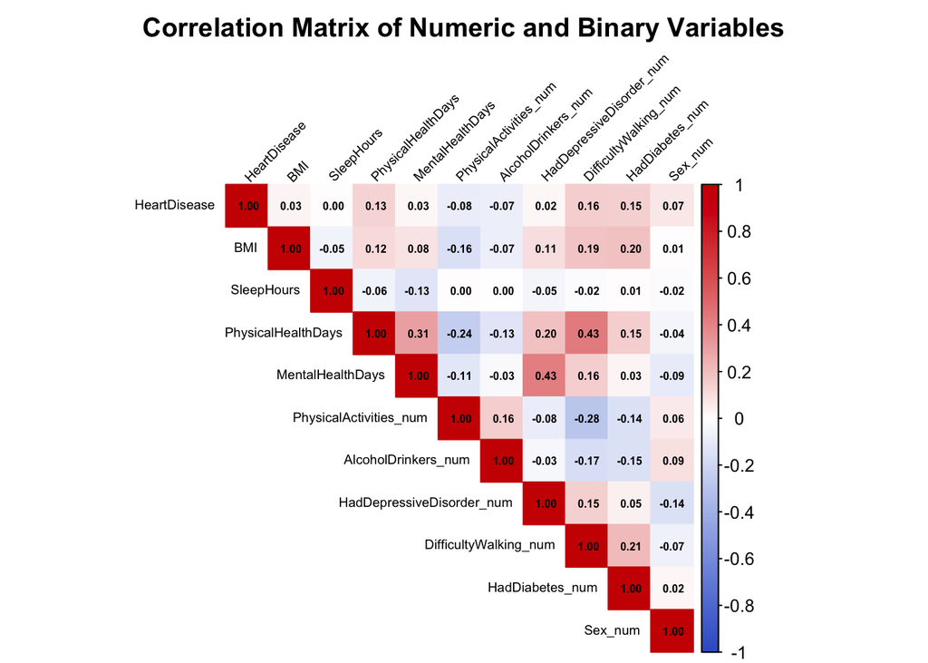

```r
# Plot the correlation heatmap
corrplot(
  cor_matrix,
  method = "color",
  # Show as an upper triagular matrix
  type = "upper",

  # Smaller labels for variables
  tl.cex = 0.6,
  tl.col = "black",

  # Smaller correlation numbers
  number.cex = 0.5,
  addCoef.col = "black",

  # Rotate labels for more space
  tl.srt = 45,

  col = colorRampPalette(c("royalblue3", "white", "red3"))(200),
  title = "Correlation Matrix of Numeric and Binary Variables",
  # Increase margins slightly
  mar = c(0, 0, 2, 0)
)
```

The correlation matrix did not suggest strong multicollinearity among the covariates, as all pairwise correlations were below 0.45. Diabetes status showed moderate positive correlations with heart disease (r = 0.15) and BMI (r = 0.20), which is consistent with established relationships between diabetes, obesity, and cardiovascular disease. These findings further support including BMI as a potential confounder in the primary regression model. MentalHealthDays showed a very weak correlation with both heart disease (r = 0.03) and diabetes (r = 0.03), providing additional justification for excluding it from the primary model.

```r
# Class imbalance documentation
# One outcome group (heart disease = yes/no -> 0/1) is much smaller than the other

# Calculate sample size and outcome prevalence
n_total <- nrow(heart)  # total number of observations in the dataset
n_total
```

```
[1] 246022
```

```r
# Count number of positive (heart disease = 1) cases
n_positive <- sum(heart$HeartDisease == 1, na.rm = TRUE)
n_positive
```

```
[1] 13435
```

```r
# Compute percentage of positive cases
percentage_positive <- round(n_positive / n_total * 100, 2)
percentage_positive
```

```
[1] 5.46
```

Of the 246,022 respondents, 13,435 (5.46%) reported a history of heart attack. Because respondents without heart disease greatly outnumber those with heart disease, the dataset shows substantial class imbalance. This is common in large population-based health datasets and is important to consider when evaluating model performance. For example, a model predicting no heart disease for every respondent would still achieve 94.54% accuracy despite having no ability to identify individuals with heart disease. For this reason, model performance will be evaluated primarily using ROC curve analysis and the area under the curve (AUC), rather than overall accuracy alone.

## Week 3: Logistic Regression Modeling

```r
# Fitting the univariate logistic regression model for each covariate
library(broom) # load broom package for tidying model outputs

# Covariates for univariate logistic regression
covariates <- c(
  "HadDiabetes_binary", "AgeCategory", "Sex", "BMI",
  "BMICategory", "SmokerStatus", "PhysicalActivities",
  "GeneralHealth", "RaceEthnicityCategory"
)

# Fit one logistic regression model for each covariate using lapply()
# var is each covariate being looped through one at a time
crude_models <- lapply(covariates, function(var) {
  # Create model formula: HeartDisease ~ covariate
  formula <- as.formula(paste("HeartDisease ~", var))

  # glm() to fit logistic regression model
  model <- glm(
    formula,
    data = heart,
    family = binomial
  )

  # Extract crude odds ratios, confidence intervals, and p-values
  tidy(model, exponentiate = TRUE, conf.int = TRUE) |>
    # Remove the intercept row
    filter(term != "(Intercept)") |>
    # Add the covariate name to the results
    # This creates a new column called "covariate"
    mutate(covariate = var)
})

# Combine all model results into one data frame using bind_rows()
crude_results <- bind_rows(crude_models)

# Results table
crude_results |>
  # Select relevant columns
  select(covariate, term, estimate, conf.low, conf.high, p.value) |>
  # Round values
  mutate(
    estimate = round(estimate, 2),
    conf.low = round(conf.low, 2),
    conf.high = round(conf.high, 2),
    p.value = ifelse(p.value <0.001, "<0.001", round(p.value, 3))
  ) |>
  # Display as a clean formatted table
  knitr::kable(
    col.names = c("Covariate", "Term", "Crude OR",
                  "95% CI Lower", "95% CI Upper", "P-value"),
    caption = "Crude Odds Ratios from Univariable Logistic Regression"
  )
```

Crude Odds Ratios from Univariable Logistic Regression

| Covariate | Term | Crude OR | 95% CI Lower | 95% CI Upper | P-value |
| --- | --- | --- | --- | --- | --- |
| HadDiabetes_binary | HadDiabetes_binaryYes | 3.69 | 3.55 | 3.83 | <0.001 |
| AgeCategory | AgeCategoryAge 25 to 29 | 1.11 | 0.74 | 1.66 | 0.606 |
| AgeCategory | AgeCategoryAge 30 to 34 | 1.78 | 1.26 | 2.53 | 0.001 |
| AgeCategory | AgeCategoryAge 35 to 39 | 2.64 | 1.93 | 3.67 | <0.001 |
| AgeCategory | AgeCategoryAge 40 to 44 | 3.56 | 2.64 | 4.89 | <0.001 |
| AgeCategory | AgeCategoryAge 45 to 49 | 6.72 | 5.06 | 9.13 | <0.001 |
| AgeCategory | AgeCategoryAge 50 to 54 | 9.57 | 7.26 | 12.92 | <0.001 |
| AgeCategory | AgeCategoryAge 55 to 59 | 13.77 | 10.48 | 18.53 | <0.001 |
| AgeCategory | AgeCategoryAge 60 to 64 | 16.38 | 12.49 | 22.00 | <0.001 |
| AgeCategory | AgeCategoryAge 65 to 69 | 21.34 | 16.30 | 28.64 | <0.001 |
| AgeCategory | AgeCategoryAge 70 to 74 | 26.98 | 20.62 | 36.20 | <0.001 |
| AgeCategory | AgeCategoryAge 75 to 79 | 33.59 | 25.65 | 45.10 | <0.001 |
| AgeCategory | AgeCategoryAge 80 or older | 41.21 | 31.49 | 55.30 | <0.001 |
| Sex | SexMale | 1.93 | 1.86 | 2.00 | <0.001 |
| BMI | BMI | 1.02 | 1.02 | 1.02 | <0.001 |
| BMICategory | BMICategoryUnderweight | 1.30 | 1.12 | 1.50 | <0.001 |
| BMICategory | BMICategoryOverweight | 1.37 | 1.31 | 1.44 | <0.001 |
| BMICategory | BMICategoryObese | 1.55 | 1.48 | 1.62 | <0.001 |
| SmokerStatus | SmokerStatusFormer smoker | 2.32 | 2.23 | 2.41 | <0.001 |
| SmokerStatus | SmokerStatusCurrent smoker - now smokes every day | 2.36 | 2.23 | 2.49 | <0.001 |
| SmokerStatus | SmokerStatusCurrent smoker - now smokes some days | 1.91 | 1.74 | 2.08 | <0.001 |
| PhysicalActivities | PhysicalActivitiesYes | 0.47 | 0.45 | 0.49 | <0.001 |
| GeneralHealth | GeneralHealthVery good | 2.01 | 1.84 | 2.21 | <0.001 |
| GeneralHealth | GeneralHealthGood | 4.35 | 4.00 | 4.75 | <0.001 |
| GeneralHealth | GeneralHealthFair | 9.60 | 8.80 | 10.49 | <0.001 |
| GeneralHealth | GeneralHealthPoor | 18.83 | 17.14 | 20.72 | <0.001 |
| RaceEthnicityCategory | RaceEthnicityCategoryBlack only, Non-Hispanic | 0.79 | 0.73 | 0.84 | <0.001 |
| RaceEthnicityCategory | RaceEthnicityCategoryHispanic | 0.65 | 0.60 | 0.69 | <0.001 |
| RaceEthnicityCategory | RaceEthnicityCategoryOther race only, Non-Hispanic | 0.83 | 0.76 | 0.90 | <0.001 |
| RaceEthnicityCategory | RaceEthnicityCategoryMultiracial, Non-Hispanic | 1.06 | 0.95 | 1.18 | 0.313 |

Univariable logistic regression showed that most covariates were significantly associated with heart disease, except for the Age 25 to 29 group (OR = 1.11, p = 0.606) and the Multiracial, Non-Hispanic group (OR = 1.06, p = 0.313). Diabetes had a strong association with heart disease (OR = 3.69, 95% CI: 3.55–3.83), with individuals reporting diabetes having nearly four times the odds compared to those without diabetes. There was a clear increasing trend in odds across age groups. General health followed an ordinal (ranking-wise) pattern consistent with expectations, and physical activity was associated with lower odds of heart disease (OR = 0.47). These crude estimates serve as the baseline for the multivariable model.

```r
# Multivariable model for RQ1
# Is diabetes associated with higher odds of heart disease after
# adjusting for age, sex, BMI, and smoking status?
model_rq1 <- glm(
  HeartDisease ~ HadDiabetes_binary + AgeCategory +
    Sex + BMI + SmokerStatus,
  data = heart,
  family = binomial
)

# Extract adjusted OR's and 95% CI's
tidy(model_rq1, exponentiate = TRUE, conf.int = TRUE) |>
  # Remove any intercepts
  filter(term != "(Intercept)") |>
  mutate(
    estimate = round(estimate, 2),
    conf.low = round(conf.low, 2),
    conf.high = round(conf.high, 2),
    p.value = ifelse(p.value <0.001, "<0.001", round(p.value, 3))
  ) |>
  # Select results to display
  select(term, estimate, conf.low, conf.high, p.value) |>
  knitr::kable(
    col.names = c("Term", "Adjusted OR",
                  "95% CI Lower", "95% CI Upper", "P-value"),
    caption = "Adjusted Odds Ratios from the Primary Multivariable Model"
  )
```

Adjusted Odds Ratios from the Primary Multivariable Model

| Term | Adjusted OR | 95% CI Lower | 95% CI Upper | P-value |
| --- | --- | --- | --- | --- |
| HadDiabetes_binaryYes | 2.34 | 2.25 | 2.43 | <0.001 |
| AgeCategoryAge 25 to 29 | 0.96 | 0.64 | 1.44 | 0.855 |
| AgeCategoryAge 30 to 34 | 1.43 | 1.02 | 2.04 | 0.043 |
| AgeCategoryAge 35 to 39 | 1.99 | 1.46 | 2.77 | <0.001 |
| AgeCategoryAge 40 to 44 | 2.54 | 1.88 | 3.49 | <0.001 |
| AgeCategoryAge 45 to 49 | 4.67 | 3.51 | 6.35 | <0.001 |
| AgeCategoryAge 50 to 54 | 6.57 | 4.98 | 8.88 | <0.001 |
| AgeCategoryAge 55 to 59 | 9.23 | 7.02 | 12.43 | <0.001 |
| AgeCategoryAge 60 to 64 | 11.08 | 8.45 | 14.90 | <0.001 |
| AgeCategoryAge 65 to 69 | 14.41 | 11.00 | 19.36 | <0.001 |
| AgeCategoryAge 70 to 74 | 18.46 | 14.09 | 24.79 | <0.001 |
| AgeCategoryAge 75 to 79 | 23.71 | 18.08 | 31.86 | <0.001 |
| AgeCategoryAge 80 or older | 33.40 | 25.49 | 44.87 | <0.001 |
| SexMale | 2.00 | 1.93 | 2.08 | <0.001 |
| BMI | 1.02 | 1.02 | 1.02 | <0.001 |
| SmokerStatusFormer smoker | 1.62 | 1.56 | 1.69 | <0.001 |
| SmokerStatusCurrent smoker - now smokes every day | 2.72 | 2.57 | 2.88 | <0.001 |
| SmokerStatusCurrent smoker - now smokes some days | 2.49 | 2.26 | 2.73 | <0.001 |

```r
# Compare crude vs adjusted OR for HadDiabetes_binary
crude_or <- crude_results |>
  filter(term == "HadDiabetes_binaryYes") |>
  select(estimate, conf.low, conf.high)

adjusted_or <- tidy(model_rq1, exponentiate = TRUE, conf.int = TRUE) |>
  filter(term == "HadDiabetes_binaryYes") |>
  select(estimate, conf.low, conf.high)

# Display side by side
bind_rows(
  crude_or |> mutate(model = "Crude"),
  adjusted_or |> mutate(model = "Adjusted")
) |>
  # Round all numeric results to 2 decimal places
  mutate(across(where(is.numeric), round, 2)) |>
  select(model, estimate, conf.low, conf.high) |>
  knitr::kable(
    col.names = c("Model", "OR", "95% CI Lower", "95% CI Upper"),
    caption = "Crude vs. Adjusted OR for Diabetes and Heart Disease"
  )
```

Crude vs. Adjusted OR for Diabetes and Heart Disease

| Model | OR | 95% CI Lower | 95% CI Upper |
| --- | --- | --- | --- |
| Crude | 3.69 | 3.55 | 3.83 |
| Adjusted | 2.34 | 2.25 | 2.43 |

After adjusting for age, sex, BMI, and smoking status, adults with diabetes had 2.34 times the odds of heart disease compared with non-diabetic adults (95% CI: 2.25–2.43, p < 0.001). This was lower than the crude odds ratio of 3.69, indicating that part of the unadjusted association was explained by differences in age, BMI, sex, and smoking status between the two groups. For example, individuals with diabetes tend to be older on average, and older adults are more likely to have heart disease regardless of diabetes status. However, diabetes remained a strong and statistically significant predictor of heart disease after adjustment, supporting the primary hypothesis.

Among other covariates, male sex (OR = 2.00), older age groups, and current daily smoking (OR = 2.72) were also independently associated with higher odds of heart disease. BMI showed a small but significant positive association (OR = 1.02 per unit increase). The Age 25 to 29 group remained non-significant after adjustment (OR = 0.96, p = 0.855).

```r
# Multivariable model for RQ2
# Does physical inactivity independently predict heart disease after adjusting for BMI and age?

model_rq2 <- glm(
  HeartDisease ~ PhysicalActivities + BMI + AgeCategory,
  data = heart,
  family = binomial
)
tidy(model_rq2, exponentiate = TRUE, conf.int = TRUE) |>
  # Remove any intercepts
  filter(term != "(Intercept)") |>
  mutate(
    estimate = round(estimate, 2),
    conf.low = round(conf.low, 2),
    conf.high = round(conf.high, 2),
    p.value = ifelse(p.value <0.001, "<0.001", round(p.value, 3))
  ) |>
  # Select results to display
  select(term, estimate, conf.low, conf.high, p.value) |>
  knitr::kable(
    col.names = c("Term", "Adjusted OR",
                  "95% CI Lower", "95% CI Upper", "P-value"),
    caption = "Adjusted Odds Ratios for Physical Activity Model"
  )
```

Adjusted Odds Ratios for Physical Activity Model

| Term | Adjusted OR | 95% CI Lower | 95% CI Upper | P-value |
| --- | --- | --- | --- | --- |
| PhysicalActivitiesYes | 0.60 | 0.58 | 0.62 | <0.001 |
| BMI | 1.02 | 1.02 | 1.03 | <0.001 |
| AgeCategoryAge 25 to 29 | 1.06 | 0.71 | 1.57 | 0.79 |
| AgeCategoryAge 30 to 34 | 1.63 | 1.16 | 2.33 | 0.005 |
| AgeCategoryAge 35 to 39 | 2.40 | 1.76 | 3.34 | <0.001 |
| AgeCategoryAge 40 to 44 | 3.17 | 2.36 | 4.36 | <0.001 |
| AgeCategoryAge 45 to 49 | 5.90 | 4.44 | 8.01 | <0.001 |
| AgeCategoryAge 50 to 54 | 8.29 | 6.28 | 11.19 | <0.001 |
| AgeCategoryAge 55 to 59 | 11.92 | 9.07 | 16.04 | <0.001 |
| AgeCategoryAge 60 to 64 | 14.42 | 11.00 | 19.37 | <0.001 |
| AgeCategoryAge 65 to 69 | 19.13 | 14.61 | 25.68 | <0.001 |
| AgeCategoryAge 70 to 74 | 24.27 | 18.54 | 32.56 | <0.001 |
| AgeCategoryAge 75 to 79 | 30.27 | 23.12 | 40.65 | <0.001 |
| AgeCategoryAge 80 or older | 37.07 | 28.32 | 49.75 | <0.001 |

After adjusting for BMI and age, physically active adults had 0.60 times the odds of heart disease compared with inactive adults (95% CI: 0.58–0.62, p < 0.001), indicating that physical activity was associated with lower odds of heart disease. BMI remained a small but statistically significant predictor (OR = 1.02 per unit increase). The odds of heart disease also continued to increase across older age groups, which was consistent with expectations. These findings suggest that physical inactivity is independently associated with heart disease even after accounting for BMI and age.

```r
# Interaction model for RQ3
# Is the association between smoking and heart disease modified by age group?
model_rq3 <- glm(
  HeartDisease ~ SmokerStatus * AgeCategory + BMI + Sex,
  data = heart,
  family= binomial
)

# Interaction terms only
tidy(model_rq3, exponentiate = TRUE, conf.int = TRUE) |>
  # keep only interaction terms containing :
  filter(str_detect(term, ":")) |>
  mutate(
    estimate = round(estimate, 2),
    conf.low = round(conf.low, 2),
    conf.high = round(conf.high, 2),
    p.value = ifelse(p.value < 0.001, "<0.001", round(p.value, 3))
  ) |>
  # select results to display
  select(term, estimate, conf.low, conf.high, p.value) |>
  knitr::kable(
    col.names = c("Term", "Adjusted OR",
                  "95% CI Lower", "95% CI Upper", "P-value"),
    caption = "Adjusted Odds Ratios for Smoking × Age Interaction Terms"
  )
```

Adjusted Odds Ratios for Smoking × Age Interaction Terms

| Term | Adjusted OR | 95% CI Lower | 95% CI Upper | P-value |
| --- | --- | --- | --- | --- |
| SmokerStatusFormer smoker:AgeCategoryAge 25 to 29 | 0.36 | 0.10 | 1.20 | 0.095 |
| SmokerStatusCurrent smoker - now smokes every day:AgeCategoryAge 25 to 29 | 0.29 | 0.09 | 0.87 | 0.028 |
| SmokerStatusCurrent smoker - now smokes some days:AgeCategoryAge 25 to 29 | 0.64 | 0.11 | 3.73 | 0.607 |
| SmokerStatusFormer smoker:AgeCategoryAge 30 to 34 | 0.56 | 0.21 | 1.60 | 0.252 |
| SmokerStatusCurrent smoker - now smokes every day:AgeCategoryAge 30 to 34 | 0.56 | 0.23 | 1.43 | 0.206 |
| SmokerStatusCurrent smoker - now smokes some days:AgeCategoryAge 30 to 34 | 0.88 | 0.21 | 4.45 | 0.864 |
| SmokerStatusFormer smoker:AgeCategoryAge 35 to 39 | 0.70 | 0.29 | 1.87 | 0.439 |
| SmokerStatusCurrent smoker - now smokes every day:AgeCategoryAge 35 to 39 | 0.54 | 0.24 | 1.32 | 0.153 |
| SmokerStatusCurrent smoker - now smokes some days:AgeCategoryAge 35 to 39 | 1.03 | 0.30 | 4.81 | 0.962 |
| SmokerStatusFormer smoker:AgeCategoryAge 40 to 44 | 0.73 | 0.32 | 1.90 | 0.485 |
| SmokerStatusCurrent smoker - now smokes every day:AgeCategoryAge 40 to 44 | 0.39 | 0.18 | 0.94 | 0.027 |
| SmokerStatusCurrent smoker - now smokes some days:AgeCategoryAge 40 to 44 | 0.90 | 0.27 | 4.12 | 0.876 |
| SmokerStatusFormer smoker:AgeCategoryAge 45 to 49 | 0.75 | 0.34 | 1.92 | 0.516 |
| SmokerStatusCurrent smoker - now smokes every day:AgeCategoryAge 45 to 49 | 0.40 | 0.19 | 0.94 | 0.025 |
| SmokerStatusCurrent smoker - now smokes some days:AgeCategoryAge 45 to 49 | 1.61 | 0.53 | 6.99 | 0.451 |
| SmokerStatusFormer smoker:AgeCategoryAge 50 to 54 | 0.66 | 0.30 | 1.67 | 0.339 |
| SmokerStatusCurrent smoker - now smokes every day:AgeCategoryAge 50 to 54 | 0.40 | 0.19 | 0.92 | 0.021 |
| SmokerStatusCurrent smoker - now smokes some days:AgeCategoryAge 50 to 54 | 1.69 | 0.57 | 7.24 | 0.401 |
| SmokerStatusFormer smoker:AgeCategoryAge 55 to 59 | 0.76 | 0.35 | 1.90 | 0.52 |
| SmokerStatusCurrent smoker - now smokes every day:AgeCategoryAge 55 to 59 | 0.41 | 0.20 | 0.93 | 0.022 |
| SmokerStatusCurrent smoker - now smokes some days:AgeCategoryAge 55 to 59 | 1.42 | 0.49 | 6.06 | 0.571 |
| SmokerStatusFormer smoker:AgeCategoryAge 60 to 64 | 0.81 | 0.37 | 2.02 | 0.616 |
| SmokerStatusCurrent smoker - now smokes every day:AgeCategoryAge 60 to 64 | 0.36 | 0.17 | 0.81 | 0.008 |
| SmokerStatusCurrent smoker - now smokes some days:AgeCategoryAge 60 to 64 | 1.06 | 0.36 | 4.50 | 0.925 |
| SmokerStatusFormer smoker:AgeCategoryAge 65 to 69 | 0.69 | 0.32 | 1.71 | 0.372 |
| SmokerStatusCurrent smoker - now smokes every day:AgeCategoryAge 65 to 69 | 0.34 | 0.17 | 0.78 | 0.006 |
| SmokerStatusCurrent smoker - now smokes some days:AgeCategoryAge 65 to 69 | 1.33 | 0.46 | 5.64 | 0.642 |
| SmokerStatusFormer smoker:AgeCategoryAge 70 to 74 | 0.59 | 0.27 | 1.46 | 0.207 |
| SmokerStatusCurrent smoker - now smokes every day:AgeCategoryAge 70 to 74 | 0.28 | 0.14 | 0.64 | 0.001 |
| SmokerStatusCurrent smoker - now smokes some days:AgeCategoryAge 70 to 74 | 0.97 | 0.34 | 4.14 | 0.967 |
| SmokerStatusFormer smoker:AgeCategoryAge 75 to 79 | 0.55 | 0.26 | 1.38 | 0.162 |
| SmokerStatusCurrent smoker - now smokes every day:AgeCategoryAge 75 to 79 | 0.21 | 0.10 | 0.49 | <0.001 |
| SmokerStatusCurrent smoker - now smokes some days:AgeCategoryAge 75 to 79 | 0.74 | 0.25 | 3.18 | 0.627 |
| SmokerStatusFormer smoker:AgeCategoryAge 80 or older | 0.49 | 0.23 | 1.22 | 0.09 |
| SmokerStatusCurrent smoker - now smokes every day:AgeCategoryAge 80 or older | 0.18 | 0.08 | 0.42 | <0.001 |
| SmokerStatusCurrent smoker - now smokes some days:AgeCategoryAge 80 or older | 0.50 | 0.16 | 2.22 | 0.289 |

After adjusting for BMI and sex, there was evidence that the association between smoking and heart disease differed across age groups. For current daily smokers, the interaction terms were statistically significant in older age categories, including Age 70–74 (OR = 0.28, 95% CI: 0.14–0.64, p = 0.001), Age 75–79 (OR = 0.21, 95% CI: 0.10–0.49, p < 0.001), and Age 80 or older (OR = 0.18, 95% CI: 0.08–0.42, p < 0.001). These interaction ORs below 1 indicate that the combined effect of daily smoking and older age on heart disease is smaller than would be expected based on their main effects alone, suggesting the smoking-heart disease association attenuates in the oldest age groups.

These results suggest that the relationship between smoking status and heart disease is not the same across age groups. For current daily smokers, the association with heart disease becomes weaker in older age groups, with lower odds ratios observed in older adults compared with younger adults. For former and occasional smokers, the estimates do not show a consistent pattern across age categories and are not consistently statistically significant. This provides evidence that age modifies the association between smoking and heart disease after accounting for BMI and sex.

```r
# Multivariable model for RQ4
# Is general health status associated with heart disease after adjusting for behavioral and clinical factors?
model_rq4 <- glm(
  HeartDisease ~ GeneralHealth + AgeCategory + Sex + BMI +
    SmokerStatus + HadDiabetes_binary + PhysicalActivities,
  data = heart,
  family = binomial
)

tidy(model_rq4, exponentiate = TRUE, conf.int = TRUE) |>
  # Remove any intercepts
  filter(term != "(Intercept)") |>
  mutate(
    estimate = round(estimate, 2),
    conf.low = round(conf.low, 2),
    conf.high = round(conf.high, 2),
    p.value = ifelse(p.value <0.001, "<0.001", round(p.value, 3))
  ) |>
  # Select results to display
  select(term, estimate, conf.low, conf.high, p.value) |>
  knitr::kable(
    col.names = c("Term", "Adjusted OR",
                  "95% CI Lower", "95% CI Upper", "P-value"),
    caption = "Adjusted Odds Ratios for General Health Model"
  )
```

Adjusted Odds Ratios for General Health Model

| Term | Adjusted OR | 95% CI Lower | 95% CI Upper | P-value |
| --- | --- | --- | --- | --- |
| GeneralHealthVery good | 1.67 | 1.52 | 1.83 | <0.001 |
| GeneralHealthGood | 3.04 | 2.78 | 3.33 | <0.001 |
| GeneralHealthFair | 5.66 | 5.17 | 6.22 | <0.001 |
| GeneralHealthPoor | 9.69 | 8.76 | 10.73 | <0.001 |
| AgeCategoryAge 25 to 29 | 1.00 | 0.67 | 1.50 | 0.984 |
| AgeCategoryAge 30 to 34 | 1.51 | 1.07 | 2.15 | 0.021 |
| AgeCategoryAge 35 to 39 | 2.14 | 1.56 | 2.98 | <0.001 |
| AgeCategoryAge 40 to 44 | 2.66 | 1.97 | 3.66 | <0.001 |
| AgeCategoryAge 45 to 49 | 4.73 | 3.56 | 6.44 | <0.001 |
| AgeCategoryAge 50 to 54 | 6.40 | 4.85 | 8.65 | <0.001 |
| AgeCategoryAge 55 to 59 | 8.60 | 6.54 | 11.59 | <0.001 |
| AgeCategoryAge 60 to 64 | 10.31 | 7.85 | 13.87 | <0.001 |
| AgeCategoryAge 65 to 69 | 13.81 | 10.54 | 18.56 | <0.001 |
| AgeCategoryAge 70 to 74 | 17.25 | 13.16 | 23.18 | <0.001 |
| AgeCategoryAge 75 to 79 | 21.64 | 16.50 | 29.10 | <0.001 |
| AgeCategoryAge 80 or older | 28.12 | 21.45 | 37.79 | <0.001 |
| SexMale | 2.11 | 2.03 | 2.19 | <0.001 |
| BMI | 1.00 | 1.00 | 1.01 | 0.001 |
| SmokerStatusFormer smoker | 1.45 | 1.39 | 1.51 | <0.001 |
| SmokerStatusCurrent smoker - now smokes every day | 1.93 | 1.82 | 2.05 | <0.001 |
| SmokerStatusCurrent smoker - now smokes some days | 1.84 | 1.67 | 2.03 | <0.001 |
| HadDiabetes_binaryYes | 1.72 | 1.65 | 1.79 | <0.001 |
| PhysicalActivitiesYes | 0.91 | 0.87 | 0.95 | <0.001 |

After adjusting for age, sex, BMI, smoking, diabetes, and physical activity, general health status remained strongly associated with heart disease. Compared with adults reporting excellent health, the odds of heart disease increased steadily across each health category: 1.67 for very good health, 3.04 for good health, 5.66 for fair health, and 9.69 for poor health (all p < 0.001). This overall pattern remained after adjustment, indicating that worse self-reported health was consistently associated with higher odds of heart disease. The crude odds ratio for poor health was 18.83, which decreased to 9.69 after adjustment, suggesting that part of the original association was explained by differences in age, smoking, diabetes, and physical activity across health status groups.

```r
library(car) # Needed for VIF

# VIF for primary model (RQ1)
# Check for multicollinearity among covariates
vif(model_rq1)
```

```
                       GVIF Df GVIF^(1/(2*Df))
HadDiabetes_binary 1.083548  1        1.040936
AgeCategory        1.151056 12        1.005879
Sex                1.014007  1        1.006979
BMI                1.124512  1        1.060430
SmokerStatus       1.084804  3        1.013659
```

Generalized variance inflation factors (GVIFs) were calculated for all covariates in the primary model. All adjusted GVIF values were below 1.07, which is well below the usual cutoff of concern which is 5, suggesting that multicollinearity was not a problem in the model. This indicates that the covariates were not highly correlated with one another and could be included together in the regression analysis.

## Week 4: Logistic Regression Model Evaluation and Fit Assessment

```r
# Full model with all covariates including optional ones
model_full <- glm(
  HeartDisease ~ HadDiabetes_binary + AgeCategory + Sex + BMI +
    SmokerStatus + PhysicalActivities + GeneralHealth +
    RaceEthnicityCategory + SleepHours + AlcoholDrinkers +
    HadDepressiveDisorder + DifficultyWalking,
  data = heart,
  family = binomial
)

# Compare AIC between the primary and full model
AIC(model_rq1, model_full)
```

```
           df      AIC
model_rq1  19 89873.42
model_full 32 85173.24
```

The AIC for the full model is 85173.24 which is lower than the AIC for the primary model which is 89873.42. Since lower AIC values indicate a better balance between model fit and model complexity, the full model provided a better fit for the data. This suggests that the additional covariates provided useful information for predicting heart disease in the model.

However, AIC was used as a secondary measure rather than the primary criterion for model selection. The primary model was chosen based on the research question and findings from previous studies, with diabetes as the main exposure and adjustment for age, sex, BMI, and smoking status as key confounding variables. Although the full model produced a lower AIC, it includes several additional predictors that were not central to the primary research question. The full model will be examined further when evaluating overall model performance in Week 5, while the primary model remains the main model used to address RQ1.

```r
# Install required package for the test
library(ResourceSelection)

# Hosmer-Lemeshow goodness-of-fit test for primary model
# g = 10 is the standrad number of groups used in the test

# Filter out NAs before fitting
heart_complete <- heart |> filter(!is.na(HadDiabetes_binary))

# Refit primary model on complete cases
model_rq1 <- glm(
  HeartDisease ~ HadDiabetes_binary + AgeCategory + Sex + BMI +
    SmokerStatus,
  data = heart_complete,
  family = binomial
)

# Hypotheses:
# H0: The model fits the data adequately
# (no significant difference between the observed and predicted values)

# HA: The model does not fit the data adequately

hoslem.test(
  heart_complete$HeartDisease,
  fitted(model_rq1),
  g = 10
)
```

```
    Hosmer and Lemeshow goodness of fit (GOF) test

data:  heart_complete$HeartDisease, fitted(model_rq1)
X-squared = 99.412, df = 8, p-value < 2.2e-16
```

The Hosmer-Lemeshow test was significant (χ² = 99.41, df = 8, p < 0.001), suggesting that the model does not fit the data perfectly. However, the sample size was very large (n = 244,039), and with datasets of this size, even small differences between observed and predicted values can produce statistically significant results. As a result, the Hosmer-Lemeshow test may indicate lack of fit even when the model performs reasonably well in practice.

Model performance will again be assessed using ROC/AUC in Week 5, which is a better measure of how well the model distinguishes between cases and non-cases of heart disease.

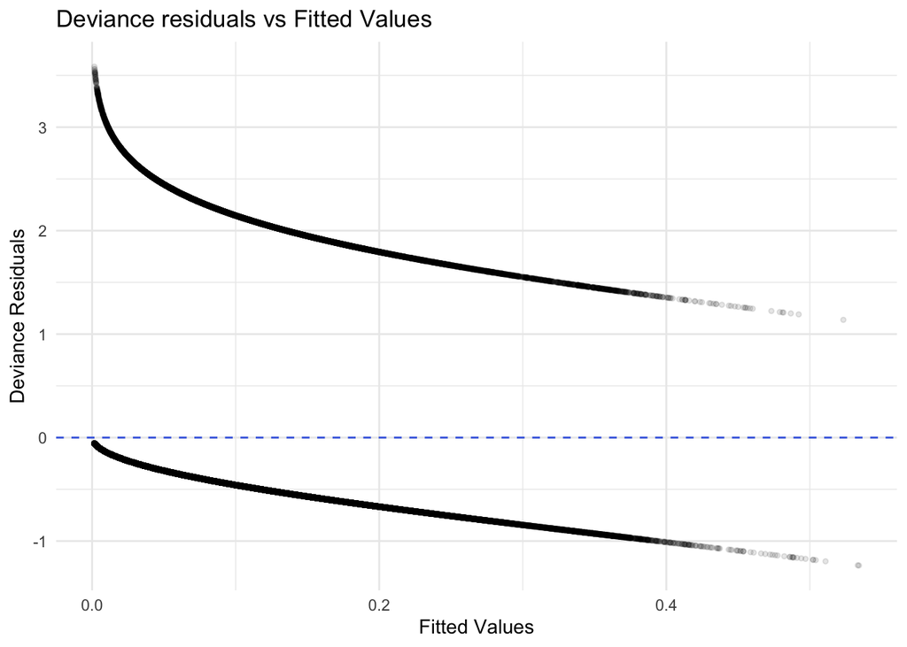

```r
# Residual plots for primary model

# Add fitted values and residuals to a data frame
# Run diagnostics for the primary model
model_rq1_diag <- data.frame(
  fitted = fitted(model_rq1),
  deviance_resid = residuals(model_rq1, type = "deviance"),
  pearson_resid = residuals(model_rq1, type = "pearson")
)

# Visualizations of deviance residuals vs fitted values

# Fitted values are the predicted probabilities
ggplot(model_rq1_diag, aes(x = fitted, y = deviance_resid)) +
  # Adjust transparency and size of point
  geom_point(alpha= 0.1, size = 1) +
  # Add horizontal line
  # Place the reference line at 0
  geom_hline( yintercept = 0, linetype = "dashed", color = "royalblue") +
  labs(
    title = "Deviance residuals vs Fitted Values",
    x = "Fitted Values",
    y = "Deviance Residuals"
  ) +
  theme_minimal()
```

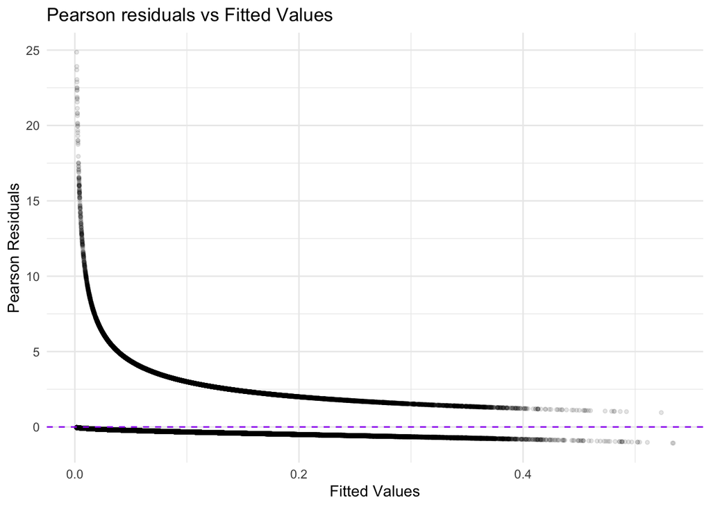

```r
ggplot(model_rq1_diag, aes(x = fitted, y = pearson_resid)) +
  geom_point(alpha= 0.1, size = 1) +
  geom_hline( yintercept = 0, linetype = "dashed", color = "purple") +
  labs(
    title = "Pearson residuals vs Fitted Values",
    x = "Fitted Values",
    y = "Pearson Residuals"
  ) +
  theme_minimal()
```

The Pearson residuals vs Fitted Values plot showed a similar two-band structure above and below zero, consistent with a binary outcome. Most observations again had very low predicted probabilities of heart disease. The upper band displayed a more noticeable downward curvature compared with the deviance residual plot, while the lower band remained closer to zero across the range of fitted values. Pearson residuals reached values as high as 25, reflecting cases where the model predicted a very low probability of heart disease but the outcome occurred. As fitted values increased toward 0.5, the points became more dispersed without a clear pattern. Overall, both plots showed patterns consistent with what is expected for a logistic regression model with a binary outcome and class imbalance.

```r
# Influence Measures

# Cook's distance and hat values for primary model
# Standard cutoff for influential observations = 4/n

n <- nrow(heart_complete)
cutoff <- 4 / n
cutoff
```

```
[1] 1.639082e-05
```

```r
# Compute influence measures in dataframe
influence_measures <- data.frame(
  cooks = cooks.distance(model_rq1),
  hat = hatvalues(model_rq1)
)

# Number of observations above Cook's distance cutoff
n_cooks <- sum(influence_measures$cooks > cutoff)
n_cooks
```

```
[1] 13471
```

```r
# Percentage above Cook's distance cutoff
cooks_percent <- 100 * n_cooks / n
cooks_percent
```

```
[1] 5.520019
```

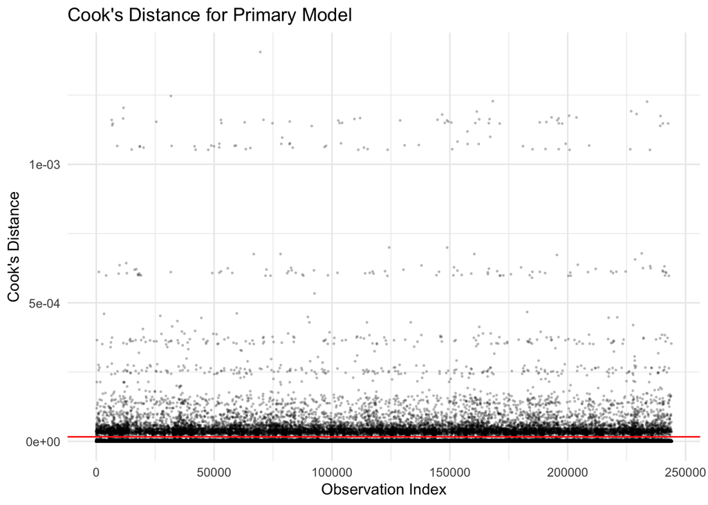

```r
# Cook's Distance Plot
ggplot(
  influence_measures,
  aes(x = seq_along(cooks), y = cooks)
) +
  geom_point(alpha = 0.2, size = 0.3) +
  geom_hline(
    yintercept = cutoff,
    linetype = "solid",
    color = "red"
  ) +
  labs(
    title = "Cook's Distance for Primary Model",
    x = "Observation Index",
    y = "Cook's Distance"
  ) +
  theme_minimal()
```

Cook’s distance shows that most observations are clustered very close to zero, indicating that the majority do not meaningfully affect the model. A total of 13,471 observations (5.52%) exceeded the standard cutoff of 4/n ($1.64 \times 10^{-5}$). The plot shows several horizontal tiers of points above the cutoff, reflecting groups of observations that share similar predictor combinations and therefore exert a similar, relatively uniform level of influence on the fitted model. A smaller number of points sits well above these bands, indicating observations with stronger individual influence whose removal would produce more noticeable changes in the model estimates compared to the majority of the data.

```r
# Hat values (leverage)
summary(influence_measures$hat)
```

```
     Min.   1st Qu.    Median      Mean   3rd Qu.      Max.
2.202e-05 4.037e-05 5.975e-05 7.786e-05 9.324e-05 2.681e-03
```

```r
# Hat value cutoff = 2p/n (rule of thumb for high leverage)
# p = number of model parameters (including intercept)
# n = sample size

hat_cutoff <- 2 * length(coef(model_rq1)) / n
hat_cutoff
```

```
[1] 0.0001557128
```

```r
# Number of observations above leverage cutoff
n_hat <- sum(influence_measures$hat > hat_cutoff)
n_hat
```

```
[1] 21713
```

```r
# Percentage above leverage cutoff
hat_percent <- 100 * n_hat / n
hat_percent
```

```
[1] 8.897348
```

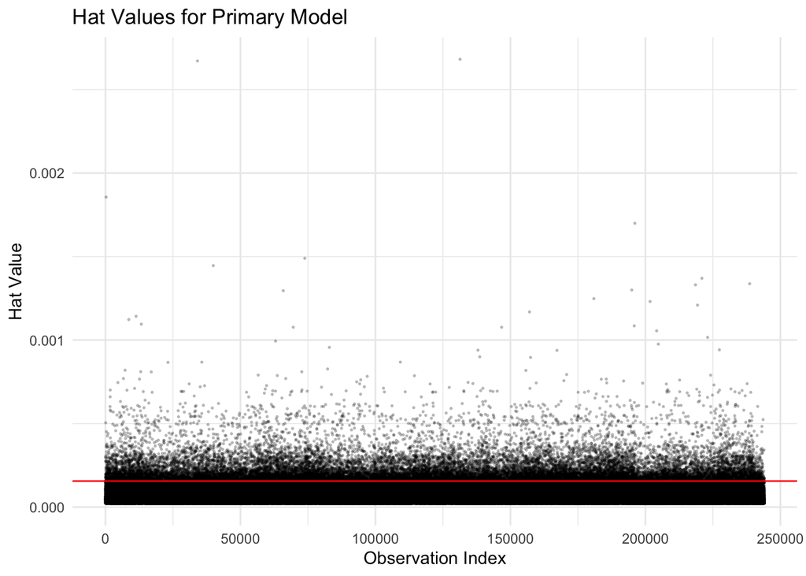

```r
# Hat value plot
ggplot(influence_measures, aes(x = seq_along(hat), y = hat)) +
  geom_point(alpha = 0.2, size = 0.3) +
  geom_hline(
    yintercept = hat_cutoff,
    linetype = "solid",
    color = "red"
  ) +
  labs(
    title = "Hat Values for Primary Model",
    x = "Observation Index",
    y = "Hat Value"
  ) +
  theme_minimal()
```

Hat values show that most observations are clustered very close to zero, indicating low leverage and typical predictor values. A total of 21,713 observations (8.90%) exceeded the cutoff of 2p/n (0.0001557128). Above the cutoff, points become more scattered, reflecting a gradual increase in leverage for observations with less common predictor combinations. A small number of points sit further above the main cluster, indicating relatively higher leverage and greater potential influence on the model if paired with large residuals, though all hat values remain small in absolute terms.

```r
# Remove observations above Cook's distance cutoff
heart_no_influence <- heart_complete[influence_measures$cooks <= cutoff, ]

# Refit model
model_rq1_no_influence <- glm(
  HeartDisease ~ HadDiabetes_binary + AgeCategory +
    Sex + BMI + SmokerStatus,
  data = heart_no_influence,
  family = binomial
)

summary(model_rq1_no_influence)
```

```
Call:
glm(formula = HeartDisease ~ HadDiabetes_binary + AgeCategory +
    Sex + BMI + SmokerStatus, family = binomial, data = heart_no_influence)

Coefficients:
                                                    Estimate Std. Error z value
(Intercept)                                       -2.657e+01  4.483e+03  -0.006
HadDiabetes_binaryYes                             -9.459e-13  2.331e+03   0.000
AgeCategoryAge 25 to 29                           -1.793e-13  4.627e+03   0.000
AgeCategoryAge 30 to 34                           -3.081e-13  4.436e+03   0.000
AgeCategoryAge 35 to 39                           -3.724e-13  4.291e+03   0.000
AgeCategoryAge 40 to 44                           -4.387e-13  4.225e+03   0.000
AgeCategoryAge 45 to 49                           -3.741e-13  4.243e+03   0.000
AgeCategoryAge 50 to 54                           -3.249e-13  4.101e+03   0.000
AgeCategoryAge 55 to 59                           -3.296e-13  4.028e+03   0.000
AgeCategoryAge 60 to 64                           -4.190e-13  3.907e+03   0.000
AgeCategoryAge 65 to 69                            4.292e-12  3.878e+03   0.000
AgeCategoryAge 70 to 74                           -5.366e-13  3.965e+03   0.000
AgeCategoryAge 75 to 79                           -6.658e-13  4.276e+03   0.000
AgeCategoryAge 80 or older                        -7.215e-13  4.311e+03   0.000
SexMale                                           -1.132e-12  1.494e+03   0.000
BMI                                               -2.943e-15  1.187e+02   0.000
SmokerStatusFormer smoker                          2.050e-12  1.747e+03   0.000
SmokerStatusCurrent smoker - now smokes every day  3.419e-14  2.733e+03   0.000
SmokerStatusCurrent smoker - now smokes some days  9.324e-14  4.248e+03   0.000
                                                  Pr(>|z|)
(Intercept)                                          0.995
HadDiabetes_binaryYes                                1.000
AgeCategoryAge 25 to 29                              1.000
AgeCategoryAge 30 to 34                              1.000
AgeCategoryAge 35 to 39                              1.000
AgeCategoryAge 40 to 44                              1.000
AgeCategoryAge 45 to 49                              1.000
AgeCategoryAge 50 to 54                              1.000
AgeCategoryAge 55 to 59                              1.000
AgeCategoryAge 60 to 64                              1.000
AgeCategoryAge 65 to 69                              1.000
AgeCategoryAge 70 to 74                              1.000
AgeCategoryAge 75 to 79                              1.000
AgeCategoryAge 80 or older                           1.000
SexMale                                              1.000
BMI                                                  1.000
SmokerStatusFormer smoker                            1.000
SmokerStatusCurrent smoker - now smokes every day    1.000
SmokerStatusCurrent smoker - now smokes some days    1.000

(Dispersion parameter for binomial family taken to be 1)

    Null deviance: 0.0000e+00  on 230567  degrees of freedom
Residual deviance: 1.3377e-06  on 230549  degrees of freedom
AIC: 38

Number of Fisher Scoring iterations: 25
```

```r
# Compare odds ratios
exp(coef(model_rq1_no_influence))
```

```
                                      (Intercept)
                                     2.900701e-12
                            HadDiabetes_binaryYes
                                     1.000000e+00
                          AgeCategoryAge 25 to 29
                                     1.000000e+00
                          AgeCategoryAge 30 to 34
                                     1.000000e+00
                          AgeCategoryAge 35 to 39
                                     1.000000e+00
                          AgeCategoryAge 40 to 44
                                     1.000000e+00
                          AgeCategoryAge 45 to 49
                                     1.000000e+00
                          AgeCategoryAge 50 to 54
                                     1.000000e+00
                          AgeCategoryAge 55 to 59
                                     1.000000e+00
                          AgeCategoryAge 60 to 64
                                     1.000000e+00
                          AgeCategoryAge 65 to 69
                                     1.000000e+00
                          AgeCategoryAge 70 to 74
                                     1.000000e+00
                          AgeCategoryAge 75 to 79
                                     1.000000e+00
                       AgeCategoryAge 80 or older
                                     1.000000e+00
                                          SexMale
                                     1.000000e+00
                                              BMI
                                     1.000000e+00
                        SmokerStatusFormer smoker
                                     1.000000e+00
SmokerStatusCurrent smoker - now smokes every day
                                     1.000000e+00
SmokerStatusCurrent smoker - now smokes some days
                                     1.000000e+00
```

```r
exp(coef(model_rq1))
```

```
                                      (Intercept)
                                      0.001180556
                            HadDiabetes_binaryYes
                                      2.338917431
                          AgeCategoryAge 25 to 29
                                      0.963349088
                          AgeCategoryAge 30 to 34
                                      1.431936564
                          AgeCategoryAge 35 to 39
                                      1.990076585
                          AgeCategoryAge 40 to 44
                                      2.539550185
                          AgeCategoryAge 45 to 49
                                      4.670541867
                          AgeCategoryAge 50 to 54
                                      6.572089648
                          AgeCategoryAge 55 to 59
                                      9.226690737
                          AgeCategoryAge 60 to 64
                                     11.081918225
                          AgeCategoryAge 65 to 69
                                     14.409291702
                          AgeCategoryAge 70 to 74
                                     18.460247086
                          AgeCategoryAge 75 to 79
                                     23.709115468
                       AgeCategoryAge 80 or older
                                     33.400768899
                                          SexMale
                                      2.002815054
                                              BMI
                                      1.021653016
                        SmokerStatusFormer smoker
                                      1.619354680
SmokerStatusCurrent smoker - now smokes every day
                                      2.720129806
SmokerStatusCurrent smoker - now smokes some days
                                      2.485120318
```

After removing observations with Cook’s distance above the 4/n cutoff, the logistic regression model became unstable, with coefficients shrinking toward zero and odds ratios moving toward one. This suggests that the excluded observations contained important information for estimating the relationship between predictors and heart disease. Therefore, despite being flagged as influential, these observations were retained in the final model, as their removal reduced the model’s ability to capture meaningful associations rather than improving fit.

Hat values were not used for a sensitivity analysis because they only measure leverage (unusual predictor values) and do not indicate whether an observation meaningfully affects the fitted model. That role is already captured by Cook’s distance, which combines leverage and residual information to assess overall influence on the model.

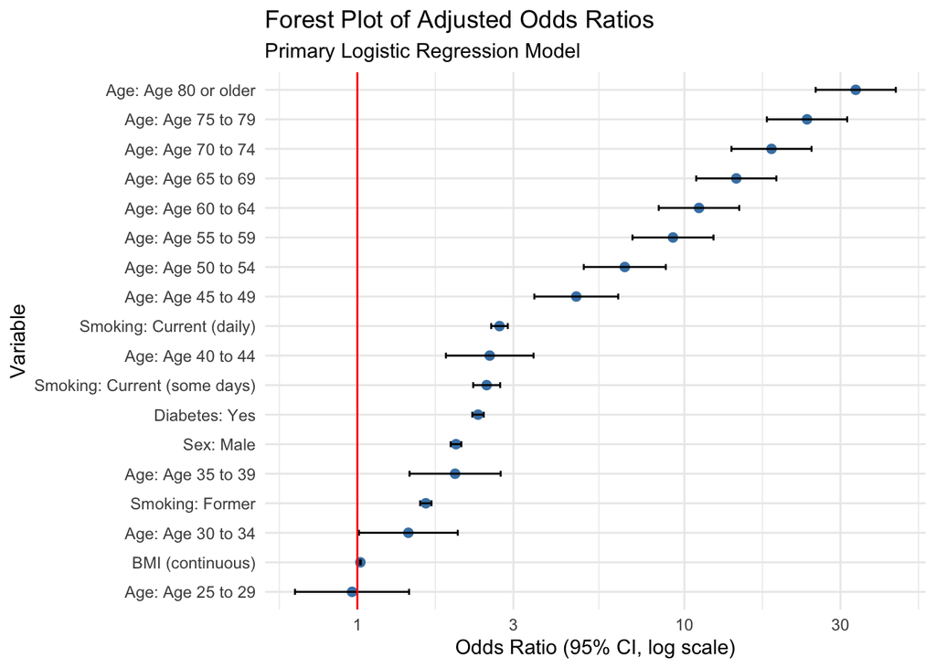

```r
# Create a forest plot
library(dplyr)

# Extract coefficient table from primary model
coef_table <- summary(model_rq1)$coefficients

# Odds ratios
OR <- exp(coef(model_rq1))

# 95% confidence intervals for odds ratios
lower <- exp(coef(model_rq1) - 1.96 * coef_table[, "Std. Error"])
upper <- exp(coef(model_rq1) + 1.96 * coef_table[, "Std. Error"])

# Create data frame for forest plot
forest_data <- data.frame(
  variable = names(OR),
  OR = OR,
  lower = lower,
  upper = upper
)

# Remove intercept since it is not interpreted as a risk factor
forest_data <- forest_data[forest_data$variable != "(Intercept)", ]

# Rename terms for plotting
forest_data$variable <- dplyr::recode(
  forest_data$variable,
  "HadDiabetes_binaryYes" = "Diabetes: Yes",
  "SexMale" = "Sex: Male",
  "BMI" = "BMI (continuous)",
  "SmokerStatusFormer smoker" = "Smoking: Former",
  "SmokerStatusCurrent smoker - now smokes every day" =
    "Smoking: Current (daily)",
  "SmokerStatusCurrent smoker - now smokes some days" =
    "Smoking: Current (some days)"
)
# Rename age categories using gsub()
forest_data$variable <- gsub(
  "AgeCategory",
  "Age: ",
  forest_data$variable
)

library(ggplot2)

# Forest plot of adjusted odds ratios and 95% confidence intervals
ggplot(
  forest_data,
  aes(
    x = OR,
    y = reorder(variable, OR)   # Order variables by odds ratio
  )
) +
  geom_point(size = 2, color = "steelblue") +
  # Add 95% confidence interval bars
  geom_errorbarh(
    aes(xmin = lower, xmax = upper),
    height = 0.2
  ) +
  # Reference line at OR = 1 (no association)
  geom_vline(
    xintercept = 1,
    linetype = "solid",
    color = "red"
  ) +
  # Display odds ratios on a log scale for easier comparison
  # effects below and above 1 are shown symmetrically
  scale_x_log10() +
  labs(
    title = "Forest Plot of Adjusted Odds Ratios",
    subtitle = "Primary Logistic Regression Model",
    x = "Odds Ratio (95% CI, log scale)",
    y = "Variable"
  ) +
  theme_minimal()
```

The forest plot displays adjusted odds ratios and 95% confidence intervals from the primary model. After adjusting for age, sex, BMI, and smoking status, age remains the strongest predictor of heart disease, with steadily increasing odds across age categories, and the highest odds observed among individuals aged 80 and older compared with the 18 to 24 reference group. Having diabetes, current daily smoking, and being male are all associated with higher odds of heart disease after adjustment compared to their reference levels. Former and occasional smoking also show elevated odds, but with smaller effects relative to current daily smoking. BMI shows a modest positive association with heart disease but smaller effects relative to age, smoking, sex, and diabetes. The log scale was used to improve visualization and allow effects below and above an odds ratio of 1 to be compared more clearly across a wide range of values. Overall, the results indicate that the association between diabetes and heart disease remains statistically significant, with higher odds of heart disease observed even after adjusting for key demographic and lifestyle factors.

## Week 5: Model Evaluation and Advanced Regression Techniques

```r
library(pROC)

# Predicted probabilities form primary and full model
pred_rq1 <- predict(model_rq1, type = "response")
pred_full <- predict(model_full, type = "response")

# ROC curves
roc_rq1 <- roc(heart_complete$HeartDisease, pred_rq1)
roc_full <- roc(heart_complete$HeartDisease, pred_full)

# AUC values
auc(roc_rq1)
```

```
Area under the curve: 0.786
```

```r
auc(roc_full)
```

```
Area under the curve: 0.8232
```

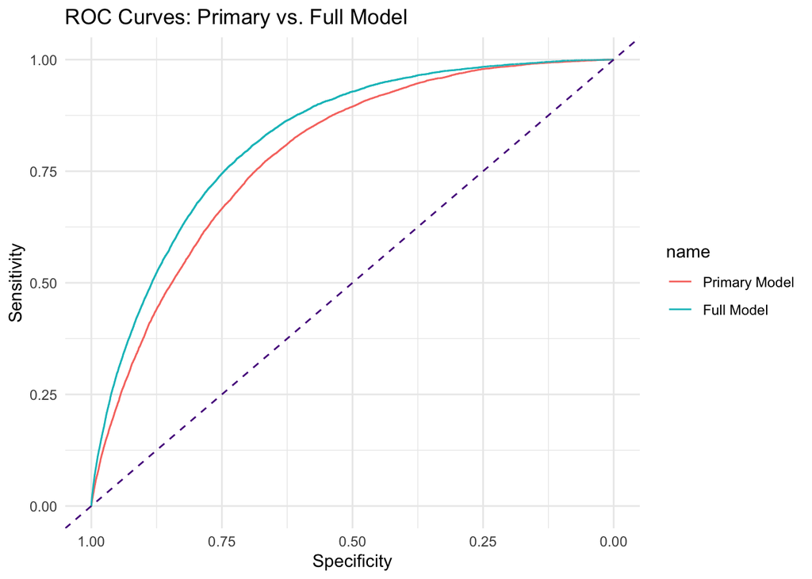

```r
# Plot both ROC curves together for comparison
ggroc(list("Primary Model" = roc_rq1, "Full Model" = roc_full)) +
  geom_abline( intercept = 1, slope = 1,
               linetype = "dashed", color = "purple4") +
  # Reference line representing random classification of heart disease status
  labs(title = "ROC Curves: Primary vs. Full Model",
       x = "Specificity",
       y= "Sensitivity") +
  theme_minimal()
```

The ROC curve analysis showed that the primary model, which included diabetes, age, sex, BMI, and smoking status, achieved an AUC of 0.786, indicating good ability to distinguish between respondents with and without heart disease. The full model, which additionally included physical activity, general health, race/ethnicity, sleep hours, alcohol use, depressive disorder, and difficulty walking, achieved a higher AUC of 0.823, suggesting improved predictive performance with the additional covariates.

The graph shows that both ROC curves rise steeply from the bottom left before flattening as specificity decreases, and both sit above the diagonal reference line, indicating better than random discrimination. The full model curve sits slightly higher than the primary model curve across most of the plot, consistent with its higher AUC of 0.823 compared to 0.786 for the primary model. Neither curve reaches the top left corner, reflecting the difficulty of predicting a rare outcome in a large observational dataset. Overall, this is consistent with the full model having a lower AIC than primary model suggesting additional covariates providing a better model fit.

```r
# Predicted probabilities
pred_prob <- predict(
  model_rq1,
  type = "response"
)

# Find the optimal cutoff using Youden's Index
youden <- coords(
  roc_rq1,
  "best",                         # Best cutoff
  best.method = "youden",         # Maximize sensitivity + specificity - 1
  ret = c("threshold",            # Cutoff value
          "sensitivity",          # True positive rate
          "specificity")          # True negative rate
)
youden
```

```
   threshold sensitivity specificity
1 0.05553308   0.7724045   0.6668777
```

```r
# Extract optimal cutoff and set to numeric
opt_cutoff <- as.numeric(youden["threshold"])

# Classify observations as heart disease (1 = Yes)
# otherwise classify as no heart disease (0 = No)

# Confusion matrix using default cutoff of 0.50
pred_50 <- ifelse(pred_prob >= 0.50, 1, 0)

confusion_50 <- table(
  Predicted = pred_50,
  Actual = heart_complete$HeartDisease
)
confusion_50
```

```
         Actual
Predicted      0      1
        0 230654  13378
        1      6      1
```

```r
# Confusion matrix using optimal cutoff
pred_opt <- ifelse(pred_prob >= opt_cutoff, 1, 0)

confusion_opt <- table(
  Predicted = pred_opt,
  Actual = heart_complete$HeartDisease
)

confusion_opt
```

```
         Actual
Predicted      0      1
        0 153822   3045
        1  76838  10334
```

The default cutoff of 0.50 resulted in the model classifying almost all observations as no heart disease, correctly identifying 230,654 individuals without heart disease (true negatives). Only one individual was correctly identified as having heart disease (true positive), resulting in extremely low sensitivity of approximately 0.00007 and very high specificity of approximately 0.9999. This indicates that the model failed to identify most individuals with heart disease. In contrast, the cutoff selected using Youden’s index (0.0555) produced a more balanced classification, with 153,822 individuals correctly identified as having no heart disease and 10,334 correctly identified as having heart disease. This improved sensitivity to 0.7724, while specificity decreased to 0.6669, reflecting improved detection of true cases, with a corresponding increase in incorrectly classified non-cases.

```r
# Bootstrap internal validation
# 200 iterations, sampling with replacement

set.seed(1234)
n_boot <- 200
# Store AUC from each bootstrap iteration
boot_auc <- numeric(n_boot)

# Create a for loop through 200 bootstrap samples
for (i in 1:n_boot){
  # Draw a bootstrap sample with replacement
  # from the original data
  boot_samp <- sample(nrow(heart_complete),
                     replace = TRUE)
  # Create bootstrap dataset
  boot_data <- heart_complete[boot_samp, ]

  # Refit the primary logistic regression model
  # using the bootstrap sample
  boot_model <- glm(HeartDisease ~ HadDiabetes_binary +
                      AgeCategory + Sex + BMI + SmokerStatus,
                    data = boot_data,
                    family = binomial
                    )
  # Generate predicted probabilities on the original dataset
  boot_pred <- predict(boot_model,
                       newdata = heart_complete,
                       type = "response"
                       )
  # Calculate the AUC for the bootstrap model
  # evaluated on the original data in the ith iteration
  boot_auc[i] <- as.numeric(auc(
    roc(heart_complete$HeartDisease,
        boot_pred,
        # Prevents the code from printing ROC messages
        quiet = TRUE
    )
  ))
}

saveRDS(boot_auc, "boot_auc.rds")

# Apparent AUC from earlier
apparent_auc <- as.numeric(auc(roc_rq1))
apparent_auc
```

```
[1] 0.7860242
```

```r
# Estimate optimism as the difference between the
# apparent AUC and the average bootstrap AUC
optimism <- apparent_auc - mean(boot_auc)
optimism
```

```
[1] 0.0001633931
```

Bootstrap internal validation using 200 resamples produced an optimism estimate of 0.00016. This value is very close to zero, indicating little evidence of overfitting and suggesting that the model’s AUC is stable across resampled datasets. The optimism-corrected AUC was 0.7859, nearly identical to the apparent AUC of 0.786, indicating that the model’s predictive performance is likely to generalize well to similar data.

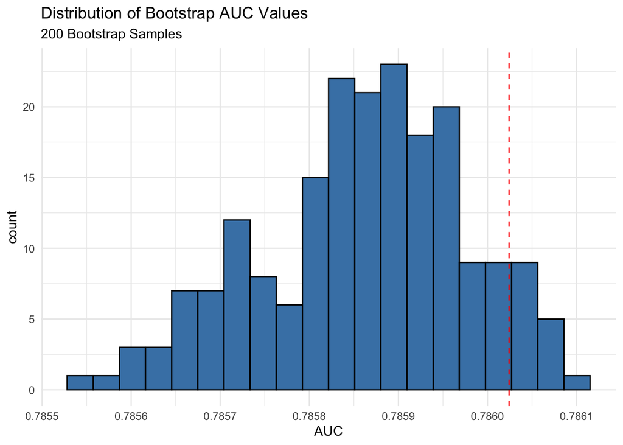

```r
# Distribution of bootstrap AUC values
boot_auc_df <- data.frame(AUC = boot_auc)

# Plot using ggplot
ggplot(boot_auc_df, aes(x = AUC)) +
  geom_histogram(
    bins = 20,
    color = "black",
    fill = "steelblue"
  ) +
  # Add a dashed reference line for the apparent AUC
  geom_vline(
    xintercept = apparent_auc,
    color = "red",
    linetype = "dashed"
  ) +
  labs(
    title = "Distribution of Bootstrap AUC Values",
    subtitle = "200 Bootstrap Samples",
    xlab = "AUC",
    ylab = "Frequency"
  ) +
  theme_minimal()
```

The bootstrap AUC values were slightly left-skewed, with most values occurring just below the apparent AUC from the original model. The apparent AUC appeared near the upper end of the distribution, reflecting the fact that the model was evaluated on the same data used to fit it (heart_complete). Despite this pattern, the difference between the apparent AUC and the average bootstrap AUC was very small (optimism = 0.00016). This indicates that model performance was stable across the bootstrap samples and provides little evidence that the model is overfitting the data.

```r
# Refit primary model stratified by sex
# Divide into subgroups

# Female only model
model_female <- glm(HeartDisease ~ HadDiabetes_binary + AgeCategory +
                      BMI + SmokerStatus,
                    data = subset(heart_complete, Sex == "Female"),
                    family = binomial)

# Male only model
model_male <- glm(HeartDisease ~ HadDiabetes_binary + AgeCategory
                    + BMI + SmokerStatus,
                    data = subset(heart_complete, Sex == "Male"),
                    family = binomial)

# Extract diabetes ORs and 95% CIs

# Female diabetes OR
female_coef <- summary(model_female)$coefficients

female_or <- exp(coef(model_female)["HadDiabetes_binaryYes"])

female_lower <- exp(coef(model_female)["HadDiabetes_binaryYes"] -
                   1.96 * female_coef["HadDiabetes_binaryYes", "Std. Error"])

female_upper <- exp(coef(model_female)["HadDiabetes_binaryYes"] +
                   1.96 * female_coef["HadDiabetes_binaryYes", "Std. Error"])

# Male diabetes OR
male_coef <- summary(model_male)$coefficients

male_or <- exp(coef(model_male)["HadDiabetes_binaryYes"])

male_lower <- exp(coef(model_male)["HadDiabetes_binaryYes"] -
                   1.96 * male_coef["HadDiabetes_binaryYes", "Std. Error"])

male_upper <- exp(coef(model_male)["HadDiabetes_binaryYes"] +
                   1.96 * male_coef["HadDiabetes_binaryYes", "Std. Error"])
```

```r
# Create comparison table for ORs and CIs for both sexes
subgroup_results <-data.frame( Sex = c("Female", "Male"),
                               OR = c(female_or, male_or),
                               CI_Lower = c(female_lower, male_lower),
                               CI_Upper = c(female_upper, male_upper)
                               )
# modify columns with mutate()
subgroup_results |>
  mutate(OR = round(OR, 3),
         CI_Lower = round(CI_Lower, 3),
         CI_Upper = round(CI_Upper, 3),
         ) |>
  # Display subgroup results in a formatted table
  knitr::kable(
    caption = "Association Between Diabetes and Heart disease Stratified by Sex")
```

Association Between Diabetes and Heart disease Stratified by Sex

| Sex | OR | CI_Lower | CI_Upper |
| --- | --- | --- | --- |
| Female | 2.633 | 2.466 | 2.812 |
| Male | 2.172 | 2.064 | 2.286 |

The association between diabetes and heart disease was observed in both females and males. After adjusting for age, BMI, and smoking status, females with diabetes had approximately 2.633 times the odds of heart disease (95% CI: 2.466–2.812) compared with females without diabetes, while males with diabetes had approximately 2.172 times the odds (95% CI: 2.064–2.286) compared with males without diabetes. The odds ratio was somewhat larger among females, suggesting that the association between diabetes and heart disease may be stronger in females than in males.

```r
# Sensitivity analysis
# Compare primary model results using heart complete (gestational diabetes
# excluded) vs full dataset with gestational diabetes coded as a third category

# Recode HadDiabetes in a full dataset keeping gestational as separate level
# No diabetes is the reference level
heart_sensitivity <- heart |>
  mutate(
    HadDiabetes_3level = case_when(
      HadDiabetes == "Yes" ~ "Yes",
      HadDiabetes == "No" ~ "No",
      HadDiabetes == "No, pre-diabetes or borderline diabetes" ~ "No",
      HadDiabetes == "Yes, but only during pregnancy (female)" ~ "Gestational"
    ),
    HadDiabetes_3level = factor(
      HadDiabetes_3level,
      levels = c("No", "Yes", "Gestational")
    )
  )

# Refit primary model with 3-level diabetes variable
model_sensitivity <- glm(
  HeartDisease ~ HadDiabetes_3level + AgeCategory +
    Sex + BMI + SmokerStatus,
  data = heart_sensitivity,
  family = binomial
)

# Compare diabetes ORs between primary and sensitivity model
sensitivity_coeff <- summary(model_sensitivity)$coefficients

# Primary model OR and 95% CI
# With HadDiabetes_binary (No/Yes)
primary_or <- exp(coef(model_rq1)["HadDiabetes_binaryYes"])

primary_lower <- exp(coef(model_rq1)["HadDiabetes_binaryYes"] -
                   1.96 * summary(model_rq1)$coefficients["HadDiabetes_binaryYes", "Std. Error"])

primary_upper <- exp(coef(model_rq1)["HadDiabetes_binaryYes"] +
                   1.96 * summary(model_rq1)$coefficients["HadDiabetes_binaryYes", "Std. Error"])

# Sensitivity model OR and 95% CI
# With HadDiabetes_3level (No/Yes/Gestational)
sensitivity_or <- exp(coef(model_sensitivity)["HadDiabetes_3levelYes"])

sensitivity_lower <- exp(coef(model_sensitivity)["HadDiabetes_3levelYes"] -
                   1.96 * sensitivity_coeff["HadDiabetes_3levelYes", "Std. Error"])

sensitivity_upper <- exp(coef(model_sensitivity)["HadDiabetes_3levelYes"] +
                   1.96 * sensitivity_coeff["HadDiabetes_3levelYes", "Std. Error"])
```

```r
# Create comparison table for ORs and CIs for Primary vs Sensitivity model
subgroup_results <- data.frame(
  Model = c(
    "Primary (gestational excluded)",
    "Sensitivity (gestational included)"
  ),
  OR_model = c(primary_or, sensitivity_or),
  CI_Lower_model = c(primary_lower, sensitivity_lower),
  CI_Upper_model = c(primary_upper, sensitivity_upper)
)

# Remove names of the variables in the formatted table
rownames(subgroup_results) <- NULL

subgroup_results |>
  mutate(
    OR_model = round(OR_model, 3),
    CI_Lower_model = round(CI_Lower_model, 3),
    CI_Upper_model = round(CI_Upper_model, 3)
  ) |>
  # Display sensitivity analysis results in a formatted table
  knitr::kable(
    caption = "Sensitivity Analysis: Diabetes OR with and without Gestational Diabetes"
  )
```

Sensitivity Analysis: Diabetes OR with and without Gestational Diabetes

| Model | OR_model | CI_Lower_model | CI_Upper_model |
| --- | --- | --- | --- |
| Primary (gestational excluded) | 2.339 | 2.247 | 2.435 |
| Sensitivity (gestational included) | 2.340 | 2.248 | 2.436 |

The sensitivity analysis shows that the estimated odds ratio for diabetes remains essentially unchanged when gestational diabetes cases are included. In the primary model (excluding gestational cases), diabetes is associated with 2.339 times higher odds of heart disease (95% CI: 2.247–2.435). In the sensitivity model, the odds ratio is 2.340 (95% CI: 2.248–2.436), indicating that inclusion of gestational diabetes cases does not meaningfully alter the estimated association.

## Week 6: Interpretation, Limitations, and Public Health Impact

### Results Summary

**RQ1 — Diabetes and Heart Disease** After adjusting for age, sex, BMI, and smoking status, adults with diabetes had 2.339 times the odds of heart disease compared with adults without diabetes (95% CI: 2.247–2.435, p < 0.001). The crude odds ratio was 3.690, which decreased after adjustment for potential confounding variables. This reduction indicates that part of the unadjusted association between diabetes and heart disease was due to differences in age, sex, BMI, and smoking status between diabetic and non-diabetic adults. However, even after accounting for these variables, diabetes remained strongly associated with heart disease, supporting the primary hypothesis.

**RQ2 — Physical Activity and Heart Disease** Adults who reported being physically active had lower odds of heart disease than inactive adults after adjusting for age and BMI (OR = 0.60, 95% CI: 0.58–0.62, p < 0.001). Because an odds ratio of 1 represents no difference in odds between groups, the estimated odds ratio of 0.60 corresponds to a 40% reduction in the odds of heart disease among physically active adults. The association remained statistically significant after controlling for age and BMI, indicating that physically active adults had lower odds of heart disease even when comparing individuals with similar ages and BMI values.

**RQ3 — Smoking, Age, and Heart Disease** The association between daily smoking and heart disease differed across age groups. Several smoking-by-age interaction terms were statistically significant, indicating that the effect of smoking on heart disease was not constant across ages. These interaction terms represent how the combined effect of smoking and age differs from what would be expected based on each factor’s main effect alone, rather than the direct effect of smoking within each age group. Statistically significant interaction terms were observed among adults aged 25–29 years (OR = 0.29, 95% CI: 0.09–0.87, p = 0.028), 40–44 years (OR = 0.39, 95% CI: 0.18–0.94, p = 0.027), 75–79 years (OR = 0.21, 95% CI: 0.10–0.49, p < 0.001), and 80 years and older (OR = 0.18, 95% CI: 0.08–0.42, p < 0.001). These results indicate that the relationship between smoking and heart disease varies by age and is not uniform across the age groups.

**RQ4 — General Health and Heart Disease** Self-reported general health was strongly associated with heart disease after adjusting for age, sex, BMI, smoking status, diabetes, and physical activity. Compared with adults reporting excellent health, the odds of heart disease were higher in all other health categories: very good (OR = 1.670), good (OR = 3.040), fair (OR = 5.660), and poor (OR = 9.690) (all p < 0.001). This shows a clear pattern where heart disease becomes more common as self-reported health worsens. Even after accounting for other risk factors in the model, this pattern remained, meaning general health provides additional information about heart disease risk beyond the other variables included.

### Limitations

Limitations should be considered when interpreting the findings of this study.

**Residual Confounding** Although the multivariable model adjusted for age, sex, BMI, smoking status, and other covariates, unmeasured confounders may still influence the observed associations. Variables such as cholesterol levels, blood pressure, family history of heart disease, and medication use were not available in this dataset and could account for part of the association between diabetes and heart disease. As a result, the adjusted odds ratios reported here should not be interpreted as causal estimates, since unmeasured factors may contribute to the observed association between diabetes and heart disease.

**Self-Report Bias** All exposures and the outcome of heart disease were based on self-reported survey responses. Respondents were asked whether they had ever been told by a doctor that they had a heart attack, had diabetes, or engaged in physical activity, among other questions. Self-reported data are subject to recall bias and social desirability bias, and may result in misclassification of both the exposure and outcome. Individuals with undiagnosed diabetes or heart disease would be classified as not having these conditions, which could weaken the observed relationship between diabetes and heart disease and lead to an underestimate of the true association.

**Selection Bias** The BRFSS is a telephone-based survey, which may underrepresent populations without reliable phone access, including lower-income adults, those experiencing homelessness, and non-English speakers. If these groups differ systematically in their cardiovascular risk profiles, the study sample may not fully representative of the U.S. adult population, and findings may not generalize to all subgroups equally.

**Cross-Sectional Design and Causality** The BRFSS collects information at a single point in time, so it is not possible to determine whether diabetes occurred before heart disease. Because the timing of these conditions is unknown, the observed association cannot be interpreted as a cause-and-effect relationship. For example, some individuals may have been diagnosed with diabetes only after receiving medical care for heart disease. Longitudinal studies that follow individuals over time would be needed to determine whether diabetes increases the risk of developing heart disease.

**Diabetes Classification** The primary exposure, diabetes status, was recoded into a binary variable by excluding 1,983 respondents who reported gestational diabetes and combining pre-diabetes with no diabetes. Although the sensitivity analysis showed that this decision did not meaningfully change the primary odds ratio (2.339 vs. 2.340), diabetes status was simplified into broad categories that may not fully reflect differences in disease severity or clinical history.

### Comparison to Existing Literature

**Diabetes and Heart Disease (RQ1)** The adjusted odds ratio for diabetes in the primary model was 2.34 (95% CI: 2.25–2.43), meaning that respondents with diabetes had more than twice the odds of heart disease compared with those without diabetes after adjustment for age, sex, BMI, and smoking status. This result is similar to the findings of Yang et al. (2019), who reported an adjusted odds ratio of 2.09 (95% CI: 1.72–2.54) using 2015 BRFSS data [@yang2019]. Their estimate was slightly lower, which may be due to differences in the variables included in the model. In addition to demographic factors, Yang et al. adjusted for factors such as stroke, depression, diet, and physical activity. Despite these differences, both studies found a strong positive association between diabetes and heart disease.

**Physical Activity and Heart Disease (RQ2)** Shah et al. (2025) combined smoking, alcohol use, and physical inactivity into a single behavioral risk score and found that adults with two or more risk factors had 1.53 times the odds of heart attack compared with those with no risk factors [@shah2025]. Although the present study examined physical activity separately, the results point in the same direction. Physically active adults had lower odds of heart disease (OR = 0.60), indicating a protective effect of physical activity. Equivalently, physical inactivity remained positively associated with heart disease risk, consistent with the findings of Shah et al.

**Smoking and Heart Disease (RQ3)** For smoking and age, Yathindra et al. (2025) found that younger smokers aged 18 to 24 had the highest odds of angina (OR = 4.50), with the association decreasing steadily across age groups to an OR of 1.11 among adults aged 65 and older [@yathindra2025]. A similar pattern was observed in RQ3, where the association between smoking and heart disease became weaker in older age groups. One difference is that Yathindra et al. used angina as the outcome rather than heart disease, which may help explain their lower overall odds ratios. Despite this difference, both studies suggest that smoking has a stronger relative association with cardiovascular disease among younger adults than among older adults.

**General Health Status (RQ4)** None of the studies reviewed specifically examined self-reported general health status as a predictor of heart disease using BRFSS data, which makes direct comparisons difficult. In the present study, the odds of heart disease increased steadily as self-reported health worsened, ranging from 1.67 times higher odds among respondents reporting very good health to 9.69 times higher odds among those reporting poor health, compared with respondents reporting excellent health. This suggests that self-rated health may be a useful indicator of cardiovascular risk. Additional studies would be needed to determine whether a similar pattern is observed in other BRFSS years or national health datasets.

**Methodological Differences** Comparisons across studies should be interpreted with caution because the analyses were conducted using different BRFSS survey years (2015, 2020, 2022, 2023, and 2025), different cardiovascular outcome definitions (heart attack, angina, or coronary heart disease), and different sets of adjustment variables. Despite these differences, the overall findings were consistent, with diabetes, smoking, physical inactivity, older age, and male sex all associated with higher odds of cardiovascular disease among U.S. adults.

### Power Analysis

```r
library(epiR)  # Package used for post-hoc power and sample size calculations

# Post-hoc power calculation for primary model
# Testing whether the study had adequate power to detect
# the observed OR for diabetes (OR = 2.34)

# Get prevalence of heart disease by diabetes status
prop_table <- prop.table(table(heart_complete$HadDiabetes_binary,
                               heart_complete$HeartDisease),
                         margin = 1)
prop_table
```

```
               0          1
  No  0.95849705 0.04150295
  Yes 0.86236063 0.13763937
```

```r
# Prevalence among diabetic adults (Yes row, HeartDisease = 1)
# The exposed group
p_diabetes <- prop_table["Yes","1"]
p_diabetes
```

```
[1] 0.1376394
```

```r
# Prevalence among non-diabetic adults (No row, HeartDisease = 1)
# The unexposed group
p_nondiabetes <- prop_table["No", "1"]
p_nondiabetes
```

```
[1] 0.04150295
```

```r
# Sample sizes by diabetes group
n_diabetes <- sum(heart_complete$HadDiabetes_binary == "Yes")
n_nondiabetes <- sum(heart_complete$HadDiabetes_binary == "No")

n_diabetes
```

```
[1] 33813
```

```r
n_nondiabetes
```

```
[1] 210226
```

```r
# Create a 2 x 2 table of diabetes status and heart disease
# Create a 2 x 2 contingency table of diabetes status
# and heart disease status

power_table <- matrix(
  c(
    # Diabetic respondents with heart disease
    sum(
      heart_complete$HadDiabetes_binary == "Yes" &
      heart_complete$HeartDisease == 1
    ),
    # Diabetic respondents without heart disease
    sum(
      heart_complete$HadDiabetes_binary == "Yes" &
      heart_complete$HeartDisease == 0
    ),
    # Non-diabetic respondents with heart disease
    sum(
      heart_complete$HadDiabetes_binary == "No" &
      heart_complete$HeartDisease == 1
    ),
    # Non-diabetic respondents without heart disease
    sum(
      heart_complete$HadDiabetes_binary == "No" &
      heart_complete$HeartDisease == 0
    )),
  # Arrange values into 2 rows
  nrow = 2,
  # Fill the matrix row by row
  byrow = TRUE,
  # Add row and column labels
  dimnames = list(
    Exposure = c("Diabetic", "Non-diabetic"), # The rows (exposure variables)
    Outcome = c("Heart Disease", "No Heart Disease") # The columns (outcomes)
  )
)
power_table
```

```
              Outcome
Exposure       Heart Disease No Heart Disease
  Diabetic              4654            29159
  Non-diabetic          8725           201501
```

```r
# Calculate the minimum detectable odds ratio
# Let's assume 80% statistical power

# Using epi.sscc for power calculations
epi.sscc(
  OR = NA,                         # Solve for minimum detectable OR
  p1 = p_diabetes,                 # Heart disease prevalence in diabetics
  p0 = p_nondiabetes,             # Heart disease prevalence in non-diabetics
  n = nrow(heart_complete),      # Total sample size
  power = 0.80,                  # Desired power
  r = n_diabetes / n_nondiabetes, # Ratio of exposed to unexposed
  sided.test = 2,                # Two-sided test
  conf.level = 0.95
)
```

```
$n.total
[1] 244039

$n.case
[1] 210226

$n.control
[1] 33813

$power
[1] 0.8

$OR
[1] 0.9205768 1.0853242
```

The minimum detectable odds ratio at 80% power was about 0.92 to 1.09. This means that given the large sample size of 244,039 participants, the study is sensitive enough to detect even small differences between groups. In other words, even if diabetes only slightly changed the risk of heart disease, the study would still be able to pick it up. The observed association between diabetes and heart disease (OR = 2.34) is much larger than this range. This shows that the study had more than enough statistical power, because the large sample size reduces random variation and makes it very unlikely that an effect of this size would be missed.

### Public Health Impact

The findings of this study have important public health implications. Diabetes was associated with more than twice the odds of heart disease after adjustment for age, sex, BMI, and smoking status. Because both diabetes and heart disease are common conditions in the United States, this association represents a substantial burden at the population level. The results also highlight the importance of modifiable risk factors such as smoking and physical inactivity, which may be targets for prevention and intervention programs.

These findings support continued efforts to improve diabetes prevention, early detection, and disease management. Public health strategies that promote healthy lifestyles and cardiovascular risk reduction among adults with diabetes may help reduce the burden of heart disease and improve population health outcomes.